[figure not shown]

KPS(diag)-44

Diagnostic Procedure with Diagnostic Trouble Code (DTC)

KEYLESS ACCESS WITH PUSH BUTTON START SYSTEM (DIAGNOSTICS)

14.Diagnostic Procedure with Diagnostic Trouble Code (DTC)

A: DTC U0073 CONTROL MODULE COMMUNICATION BUS OFF

Detected when CAN line abnormality is detected.

NOTE:

Perform the diagnosis for LAN system. <Ref. to LAN(diag)-2, PROCEDURE, Basic Diagnostic Procedure.>

B: DTC U0100 LOST COMMUNICATION WITH ECM/PCM “A”

Detected when CAN data from the engine control module (ECM) does not arrive.

NOTE:

Perform the diagnosis for LAN system. <Ref. to LAN(diag)-2, PROCEDURE, Basic Diagnostic Procedure.>

C: DTC U0101 LOST COMMUNICATION WITH TCM

Detected when CAN data from TCM does not arrive.

NOTE:

Perform the diagnosis for LAN system. <Ref. to LAN(diag)-2, PROCEDURE, Basic Diagnostic Procedure.>

D: DTC U0122 LOST COMMUNICATION WITH VEHICLE DYNAMICS CONTROL

MODULE

Detected when CAN data from VDC does not arrive.

NOTE:

Perform the diagnosis for LAN system. <Ref. to LAN(diag)-2, PROCEDURE, Basic Diagnostic Procedure.>

E: DTC U0140 LOST COMMUNICATION WITH BODY CONTROL MODULE

Detected when CAN data from BIU does not arrive.

NOTE:

Perform the diagnosis for LAN system. <Ref. to LAN(diag)-2, PROCEDURE, Basic Diagnostic Procedure.>

F: DTC U0155 LOST COMMUNICATION WITH INSTRUMENT PANEL CLUSTER

(IPC) CONTROL MODULE

Detected when CAN data from meter does not arrive.

NOTE:

Perform the diagnosis for LAN system. <Ref. to LAN(diag)-2, PROCEDURE, Basic Diagnostic Procedure.>

G: DTC U0401 INVALID DATA RECEIVED FROM ECM/PCM “A”

Detected when there is malfunction in CAN data from the engine control module (ECM).

NOTE:

Perform the diagnosis for LAN system. <Ref. to LAN(diag)-2, PROCEDURE, Basic Diagnostic Procedure.>

H: DTC U0422 INVALID DATA RECEIVED FROM BODY CONTROL MODULE

Detected when CAN data from BIU is abnormal.

NOTE:

Perform the diagnosis for LAN system. <Ref. to LAN(diag)-2, PROCEDURE, Basic Diagnostic Procedure.>

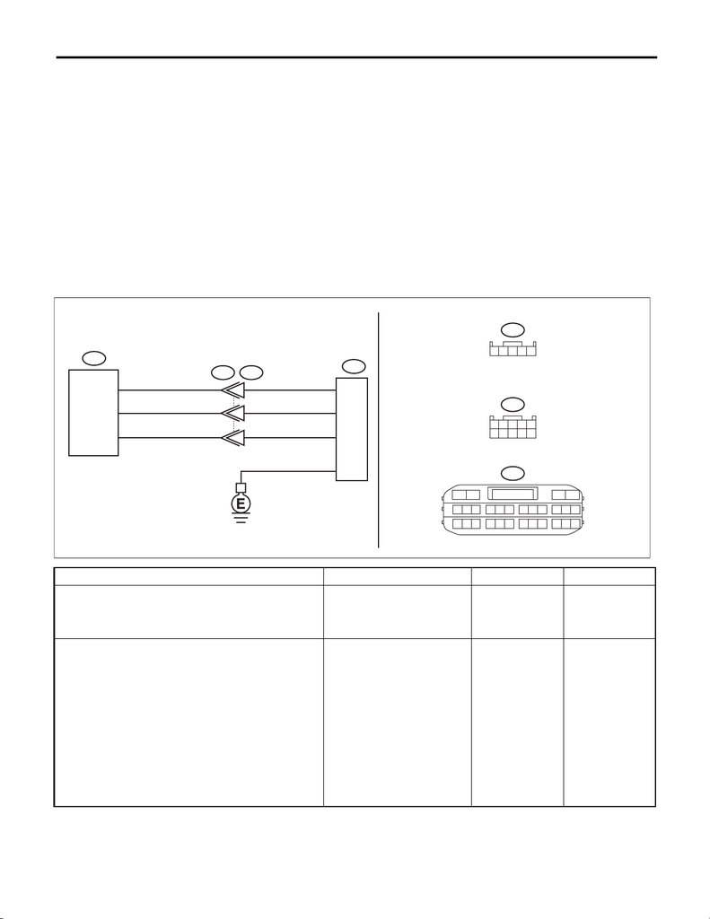

KPS(diag)-45

Diagnostic Procedure with Diagnostic Trouble Code (DTC)

KEYLESS ACCESS WITH PUSH BUTTON START SYSTEM (DIAGNOSTICS)

I: DTC B1242 WIRELESS TUNER ABNORMAL

DTC DETECTING CONDITION:

When short circuit occurs in harness between keyless access CM and receiver.

TROUBLE SYMPTOM:

• The keyless access with push button start function (except for emergency function) does not operate prop-

erly.

• Operation by the access key button does not function.

CAUTION:

• For replacement procedure of keyless access CM, refer to the “REGISTRATION MANUAL FOR IM-

MOBILIZER”.

• When the harness comes close to the receiver, the performance of keyless access system opera-

tion and wireless operation may reduce. So, when replacing or inspecting the receiver and harness,

do not change the route and length of the surrounding harnesses.

WIRING DIAGRAM:

Push button start system <Ref. to WI-329, WIRING DIAGRAM, Push Button Start System.>

Step Check Yes No

1 CHECK LAN SYSTEM.

Inspect LAN system. <Ref. to LAN(diag)-2,

PROCEDURE, Basic Diagnostic Procedure.>

Is LAN system normal? Go to step 2. Perform the

inspection accord-

ing to the diagnosis

for LAN system.

2 CHECK HARNESS.

1) Disconnect the keyless access CM connec-

tor.

2) Disconnect the receiver connector.

3) Using the tester, measure the resistance

between terminals of keyless access CM con-

nector and receiver connector, and keyless

access CM and chassis ground.

Connector & terminal

(B573) No. 19 — (R296) No. 2:

(B573) No. 17 — (R296) No. 5:

(B573) No. 5 — (R296) No. 4:

(R296) No. 1 — Chassis ground:

Is the resistance less than 1 Ω? Go to step 3. Repair or replace

the open circuit of

harness.

91078

5

6

3421

9

4

5

B19 2

1

B17

B5 4

5

R296

B92 R5

12

89

10 11 12 13 14 15 16

567

34

B:

B573

B: B573

R296

3

421

5

SL-02767

KEYLESS

ACCESS CM

RECEIVER

[figure not shown]

KPS(diag)-46

Diagnostic Procedure with Diagnostic Trouble Code (DTC)

KEYLESS ACCESS WITH PUSH BUTTON START SYSTEM (DIAGNOSTICS)

3 CHECK HARNESS.

Using a tester, measure the resistance between

the keyless access CM connector and chassis

ground.

Connector & terminal

(B573) No. 19 — Chassis ground:

(B573) No. 17 — Chassis ground:

(B573) No. 5 — Chassis ground:

Is the resistance 10 kΩ or

more?

Go to step 4. Repair or replace

the short circuit of

the harness.

4 CHECK RECEIVER.

1) Replace the receiver, and then connect it.

<Ref. to SL-98, Receiver.>

2) Using the Subaru Select Monitor, clear the

memory.

3) Use the Subaru Select Monitor and read

DTCs.

Is B1242 displayed? Replace the key-

less access CM.

<Ref. to SL-100,

Keyless Access

CM.>

Receiver has a

malfunction.

Step Check Yes No

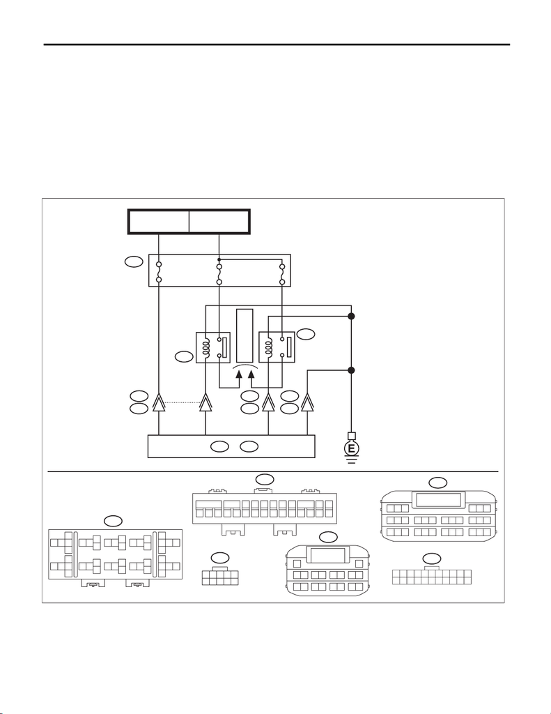

KPS(diag)-47

Diagnostic Procedure with Diagnostic Trouble Code (DTC)

KEYLESS ACCESS WITH PUSH BUTTON START SYSTEM (DIAGNOSTICS)

J: DTC B2271 IGN FUSE BLOWN OR IGN CIRCUIT ABNORMAL

DTC DETECTING CONDITION:

• When malfunction is detected in IG1 and IG2 drive circuits in the keyless access CM.

• When malfunction is detected in IG hold circuit in the keyless access CM.

TROUBLE SYMPTOM:

Not all functions operate at IGN ON.

CAUTION:

For replacement procedure of keyless access CM, refer to the “REGISTRATION MANUAL FOR IMMO-

BILIZER”.

WIRING DIAGRAM:

Push button start system <Ref. to WI-329, WIRING DIAGRAM, Push Button Start System.>

• Engine type: FA

10

12345

6789

91

2

4

13

12

17

3

16

6

15

587

14

10 11

B550

3

11

20

B576

B575

3

A: B572 C: B574

B575

3412

12 13 14 15 16 17 18 19 20 21 22

589

10 11

67

39

42

444341

40

38

3736

31

30

29

27

25

23 24 26 28

35

34

3332

6

8

9

71

3

5

42

17

20

222119

18

16

1514

13

12

1110

B225

C: B574

123

789

22 23 24 25 26 27

10 11 12 13 14 15

28 29 30

16 17 18

19 20 21

456

63

1

45 87

2

9

10

A: B572

10

B23

B28B576

B575

B550

A2

A9

3233

4353

B225

3736

38 39

B225

9

20A

15A

32

25

24

C6

A11

SL-02768

MB-31

SBF-6

(B)

MB-35

SBF-8

(B)

7.5A

IG RELAY 2

(PUSH BUTTON

START)

IG RELAY 1

(PUSH BUTTON

START)

REF. TO POWER

SUPPLY CIRCUIT

FUSE

HOLDER

RELAY BLOCK

KEYLESS ACCESS CM

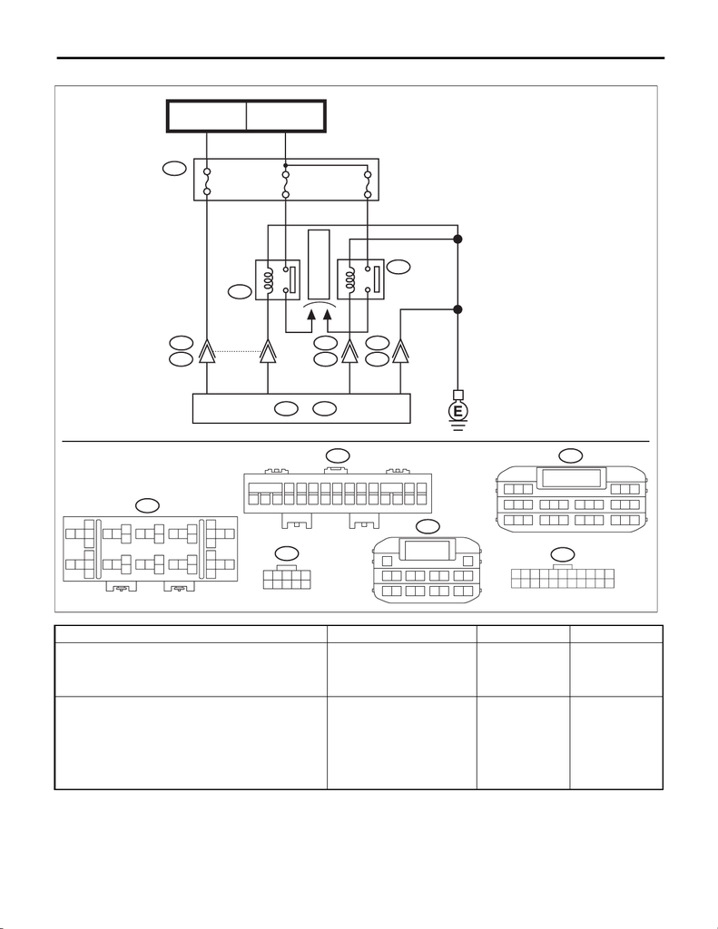

KPS(diag)-48

Diagnostic Procedure with Diagnostic Trouble Code (DTC)

KEYLESS ACCESS WITH PUSH BUTTON START SYSTEM (DIAGNOSTICS)

• Engine type: EJ

Step Check Yes No

1 CHECK LAN SYSTEM.

Inspect LAN system. <Ref. to LAN(diag)-2,

PROCEDURE, Basic Diagnostic Procedure.>

Is LAN system normal? Go to step 2. Perform the

inspection accord-

ing to the diagnosis

for LAN system.

2 CHECK FUSE.

Check the fuse.

Is the fuse OK? Go to step 3. Replace the fuse.

When the replaced

fuse is blown

immediately, check

the power supply

circuit for short-cir-

cuited.

B576

B575

101

5

14

13

18

432

17

7

16

698

15

11 12

B550

B23

10

12345

6789

3

11

3

A: B572 C: B574

B575

3412

12 13 14 15 16 17 18 19 20 21 22

589

10 11

67

39

42

444341

40

38

3736

31

30

29

27

25

23 24 26 28

35

34

3332

6

8

9

71

3

5

42

17

20

222119

18

16

1514

13

12

1110

B225

C: B574

123

789

22 23 24 25 26 27

10 11 12 13 14 15

28 29 30

16 17 18

19 20 21

456

63

1

45 87

2

9

1411 12 13 1615 1817

10

A: B572

11

B23

B28B576

B575

B550

A2

A9

3233

4353

B225

3736

38 39

B225

10

20A

15A

42

26

25

C6

A11

SL-02769

MB-31

SBF-6

(B)

MB-35

SBF-8

(B)

7.5A

IG RELAY 2

(PUSH BUTTON

START)

IG RELAY 1

(PUSH BUTTON

START)

REF. TO POWER

SUPPLY CIRCUIT

FUSE

HOLDER

RELAY BLOCK

KEYLESS ACCESS CM

[figure not shown]

KPS(diag)-49

Diagnostic Procedure with Diagnostic Trouble Code (DTC)

KEYLESS ACCESS WITH PUSH BUTTON START SYSTEM (DIAGNOSTICS)

3 CHECK HARNESS.

1) Disconnect the keyless access CM connec-

tor.

2) Using a tester, measure the voltage

between the keyless access CM connector and

chassis ground.

Connector & terminal

(B572) No. 2 (+) — Chassis ground (–):

Is the voltage 9.5 — 16 V? Go to step 4. Check the power

supply circuit.

4 CHECK HARNESS.

Using a tester, measure the resistance between

the keyless access CM connector and chassis

ground.

Connector & terminal

(B572) No. 11 — Chassis ground:

Is the resistance less than 1 Ω? Go to step 5. Repair or replace

the open circuit of

harness.

5 CHECK HARNESS.

1) Disconnect the keyless access CM connec-

tor.

2) Using a tester, measure the resistance

between the keyless access CM connector and

chassis ground.

Connector & terminal

(B572) No. 9 — Chassis ground:

Is resistance 74.15 — 460.88

Ω? (20°C)

Go to step 6. Check IG relay 2.

Go to step 7.

6 CHECK HARNESS.

1) Disconnect the keyless access CM connec-

tor.

2) Using a tester, measure the resistance

between the keyless access CM connector and

chassis ground.

Connector & terminal

(B574) No. 6 — Chassis ground:

Is resistance 50.87 — 72.17 Ω?

(20°C)

Go to step 8. Check IG relay 1.

Go to step 7.

7 CHECK RELAY.

Perform unit inspection of IG relay 1 and IG

relay 2. <Ref. to SL-9, CHECK RELAY,

INSPECTION, Relay and Fuse.>

Is the relay OK? Go to step 8. Replace the relay.

<Ref. to SL-110,

REMOVAL, IG

Relay1 (Push But-

ton Start).> <Ref.

to SL-112,

REMOVAL, IG

Relay2 (Push But-

ton Start).>

8 CHECK KEYLESS ACCESS CM.

1) Connect the keyless access CM connector.

2) Using a tester, measure the voltage

between the terminals of keyless access CM

connector.

Connector & terminal

(B574) No. 6 (+) — Chassis ground (–):

(B572) No. 9 (+) — Chassis ground (–):

Is the voltage 1 V or less → 9.5

— 16 V when ACC → IGN ON?

System is normal.

It is possible that

temporary poor

contact occurs.

Replace the key-

less access CM.

<Ref. to SL-100,

REMOVAL, Key-

less Access CM.>

Step Check Yes No

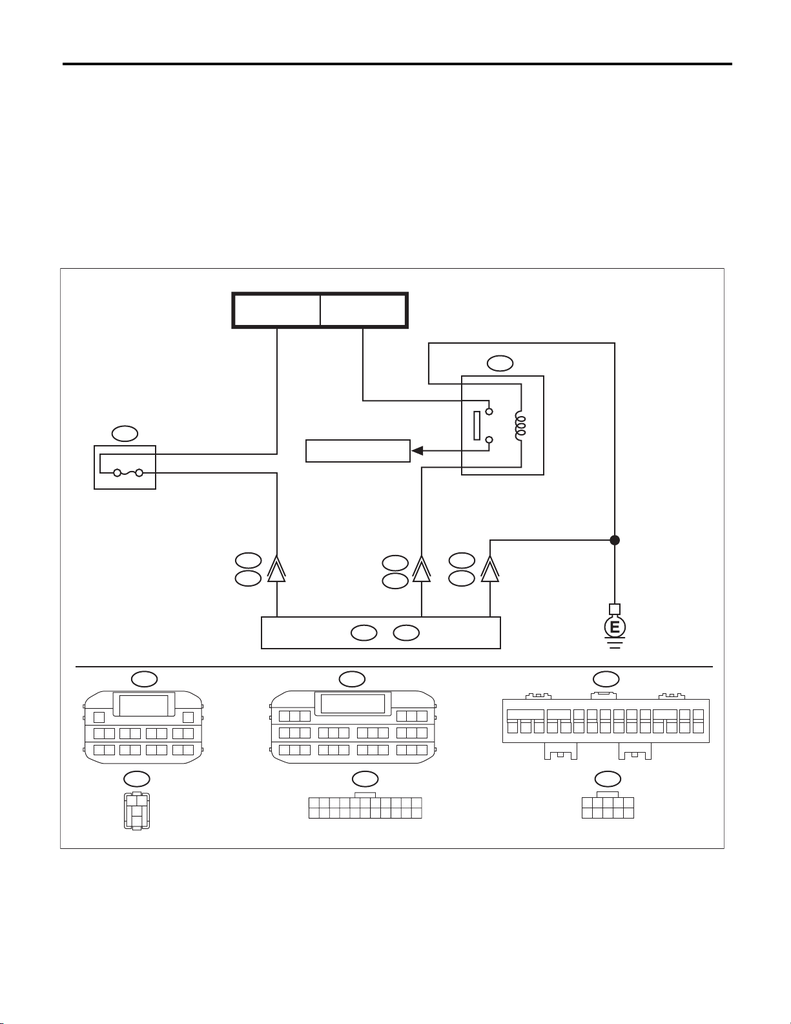

KPS(diag)-50

Diagnostic Procedure with Diagnostic Trouble Code (DTC)

KEYLESS ACCESS WITH PUSH BUTTON START SYSTEM (DIAGNOSTICS)

K: DTC B2274 ACC MONITOR

DTC DETECTING CONDITION:

When malfunction is detected in ACC relay drive circuit in the keyless access CM or external circuit.

TROUBLE SYMPTOM:

Each function does not operate at the ACC position.

CAUTION:

For replacement procedure of keyless access CM, refer to the “REGISTRATION MANUAL FOR IMMO-

BILIZER”.

WIRING DIAGRAM:

Push button start system <Ref. to WI-329, WIRING DIAGRAM, Push Button Start System.>

• Engine type: FA

10

12345

6789

B426

1

2

3

4

91

2

4

13

12

17

3

16

6

15

587

14

10 11

B550

B23

B28

5

20

B576

B575

3

10

25

B550

4

3

1

2

B426

A: B572 C: B574

B576

B575

A2

C4

A11

B575

3412

12 13 14 15 16 17 18 19 20 21 22

589

10 11

67

C: B574

123

789

22 23 24 25 26 27

10 11 12 13 14 15

28 29 30

16 17 18

19 20 21

456

63

1

45 87

2

9

1411 12 13 1615 1817

10

A: B572

SL-02770

MB-31

SBF-6

(B)

MB-35

SBF-8

(B)

REF. TO POWER SUPPLY

CIRCUIT

KEYLESS ACCESS CM

ACCESSORY RELAY

(PUSH BUTTON START)

7.5A

FUSE HOLDER

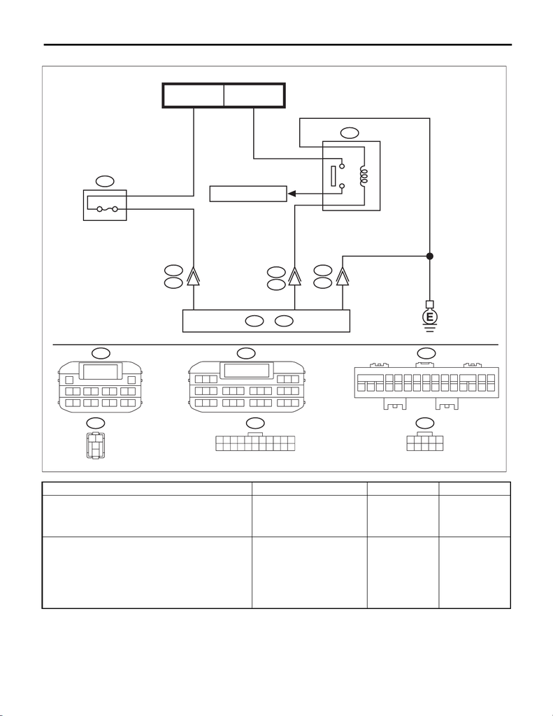

KPS(diag)-51

Diagnostic Procedure with Diagnostic Trouble Code (DTC)

KEYLESS ACCESS WITH PUSH BUTTON START SYSTEM (DIAGNOSTICS)

• Engine type: EJ

Step Check Yes No

1 CHECK LAN SYSTEM.

Inspect LAN system. <Ref. to LAN(diag)-2,

PROCEDURE, Basic Diagnostic Procedure.>

Is LAN system normal? Go to step 2. Perform the

inspection accord-

ing to the diagnosis

for LAN system.

2 CHECK FUSE.

Remove the fuse.

Is the fuse OK? Go to step 3. Replace the fuse.

When the replaced

fuse is blown

immediately, check

the power supply

circuit for short-cir-

cuited.

242322 272625212019

5

14

13

18

432

17

7

16

698

15

11 12

B550

B23

10

12345

6789

B426

1

2

3

4

B23

B28

5

20

B576

B575

3

11

26

B550

4

3

1

2

B426

A: B572 C: B574

B576

B575

A2

C4

A11

B575

3412

12 13 14 15 16 17 18 19 20 21 22

589

10 11

67

C: B574

123

789

22 23 24 25 26 27

10 11 12 13 14 15

28 29 30

16 17 18

19 20 21

456

63

1

45 87

2

9

1411 12 13 1615 1817

10

A: B572

SL-02771

MB-31

SBF-6

(B)

MB-35

SBF-8

(B)

REF. TO POWER SUPPLY

CIRCUIT

KEYLESS ACCESS CM

ACCESSORY RELAY

(PUSH BUTTON START)

7.5A

FUSE HOLDER

[figure not shown]

KPS(diag)-52

Diagnostic Procedure with Diagnostic Trouble Code (DTC)

KEYLESS ACCESS WITH PUSH BUTTON START SYSTEM (DIAGNOSTICS)

3 CHECK HARNESS.

1) Disconnect the keyless access CM connec-

tor.

chassis ground.

Connector & terminal

(B572) No. 2 (+) — Chassis ground (–):

Is the voltage 9.5 — 16 V? Go to step 4. Check the power

supply circuit.

4 CHECK HARNESS.

Using a tester, measure the resistance between

the keyless access CM connector and chassis

ground.

Connector & terminal

(B572) No. 11 — Chassis ground:

Is the resistance less than 1 Ω? Go to step 5. Repair or replace

the open circuit of

harness.

5 CHECK HARNESS.

1) Disconnect the keyless access CM connec-

tor.

2) Using a tester, measure the resistance

between the keyless access CM connector and

chassis ground.

Connector & terminal

(B574) No. 4 — Chassis ground:

Is resistance 128 — 157 Ω?

(20°C)

Go to step 7. Go to step 6.

6 CHECK RELAY.

Perform inspection of ACC relay unit. <Ref. to

SL-114, Accessory Relay (Push Button Start).>

Is the relay OK? Go to step 7. Replace the relay.

7 CHECK HARNESS.

Using a tester, measure the resistance between

keyless access CM connectors.

Connector & terminal

(B574) No. 4 — (B426) No. 1:

(B426) No. 2 — Chassis ground:

Is the resistance less than 1 Ω? Go to step 8. Repair or replace

the open circuit of

harness.

8 CHECK KEYLESS ACCESS CM.

1) Connect the keyless access CM connector.

2) Using a tester, measure the voltage

between keyless access CM connectors.

Connector & terminal

(B574) No. 4 (+) — Chassis ground (–):

Is the voltage 1 V or less → 9.5

— 16 V when OFF → ACC ON?

System is normal.

It is possible that

temporary poor

contact occurs.

Replace the key-

less access CM.

<Ref. to SL-100,

Keyless Access

CM.>

Step Check Yes No

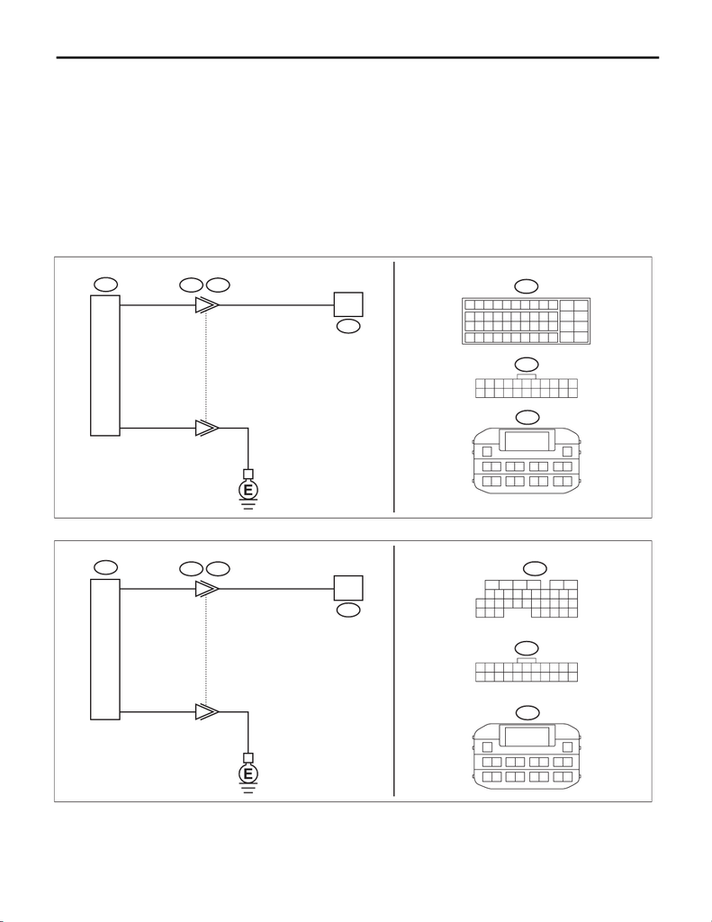

KPS(diag)-53

Diagnostic Procedure with Diagnostic Trouble Code (DTC)

KEYLESS ACCESS WITH PUSH BUTTON START SYSTEM (DIAGNOSTICS)

L: DTC B2275 STSW CIRCUIT ABNORMAL

DTC DETECTING CONDITION:

• When malfunction is detected in engine start permission signal output circuit in the keyless access CM.

• When malfunction is detected in external engine start permission signal circuit.

TROUBLE SYMPTOM:

Engine will not start.

CAUTION:

For replacement procedure of keyless access CM, refer to the “REGISTRATION MANUAL FOR IMMO-

BILIZER”.

WIRING DIAGRAM:

Push button start system <Ref. to WI-329, WIRING DIAGRAM, Push Button Start System.>

• Engine type: FA

• Engine type: EJ

11 12

23 24

35 36

47 48

3

5

6

7894

12

45

21

2219 2017 1815 1613 14

33

3431 3229 3027 2825 26

B134

A:

21

20

B575B576

A: B134

A45

A7

B572A:

A11

3412

12 13 14 15 16 17 18 19 20 21 22

589

10 11

67

B575

63

1

45 87

2

9

1411 12 13 1615 1817

10

A: B572

SL-02772

ECM

KEYLESS

ACCESS CM

B136C:

19

18

21

20

2322 24 25 26

17

1

23

4

56

27

28 29 30

31 32 33 34 35

798

151413121110 16

21

20

B575B576

C: B136

C16

A7

B572A:

A11

3412

12 13 14 15 16 17 18 19 20 21 22

589

10 11

67

B575

63

1

45 87

2

9

1411 12 13 1615 1817

10

A: B572

SL-02773

ECM

KEYLESS

ACCESS CM

[figure not shown]

KPS(diag)-54

Diagnostic Procedure with Diagnostic Trouble Code (DTC)

KEYLESS ACCESS WITH PUSH BUTTON START SYSTEM (DIAGNOSTICS)

Step Check Yes No

1 CHECK LAN SYSTEM.

Inspect LAN system. <Ref. to LAN(diag)-2,

PROCEDURE, Basic Diagnostic Procedure.>

Is LAN system normal? Go to step 2. Perform the

inspection accord-

ing to the diagnosis

for LAN system.

2 CHECK FUSE.

Remove the fuse.

Is the fuse OK? Go to step 3. Replace the fuse.

When the replaced

fuse is blown

immediately, check

the power supply

circuit for short-cir-

cuited.

3 CHECK HARNESS.

1) Disconnect the keyless access CM connec-

tor and ECM connector.

2) Using a tester, measure the resistance

between the keyless access CM connector and

ECM.

Connector & terminal

Engine type: FA

(B572) No. 7 — (B134) No. 45:

Engine type: EJ

(B572) No. 7 — (B136) No. 16:

Is the resistance less than 1 Ω? Go to step 4. Repair or replace

the open circuit of

harness.

4 CHECK HARNESS.

Using a tester, measure the resistance between

the keyless access CM connector and chassis

ground.

Connector & terminal

(B572) No. 11 — Chassis ground:

Is the resistance less than 1 Ω? Go to step 5. Repair or replace

the open circuit of

harness.

5 CHECK HARNESS.

Using a tester, measure the resistance between

the keyless access CM connector and chassis

ground.

Connector & terminal

(B572) No. 7 — Chassis ground:

Is the resistance 10 kΩ or

more?

Go to step 6. Repair or replace

the short circuit of

the harness.

6 CHECK KEYLESS ACCESS CM.

1) Connect the keyless access CM connector

and ECM connector.

2) Using a tester, measure the voltage

between the terminals of keyless access CM

connector.

Connector & terminal

(B572) No. 7 (+) — (B572) No. 11 (–):

Does the voltage change as 2 V

or less → 9 V or more when the

push button ignition switch is

turned on while depressing the

brake pedal with the shift posi-

tion in P or N (AT model) or

while depressing clutch pedal

(MT model)?

Perform inspec-

tion according to

the diagnosis of

engine. <Ref. to

EN(w/o STI)(diag)-

66, Diagnostics for

Engine Starting

Failure.> <Ref. to

EN(STI)(diag)-67,

PROCEDURE,

Diagnostics for

Engine Starting

Failure.>

Replace the key-

less access CM.

<Ref. to SL-100,

Keyless Access

CM.>

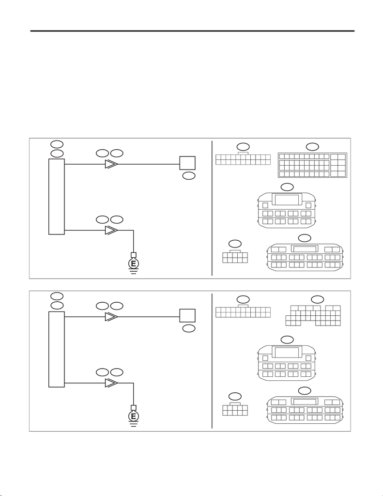

KPS(diag)-55

Diagnostic Procedure with Diagnostic Trouble Code (DTC)

KEYLESS ACCESS WITH PUSH BUTTON START SYSTEM (DIAGNOSTICS)

M: DTC B2276 ACCR SIGNAL ABNORMAL

DTC DETECTING CONDITION:

When input error occurs in accessory relay cut input signal of keyless access CM.

TROUBLE SYMPTOM:

• The accessory power supply is not cut during engine start.

• Starter rotation is slow.

CAUTION:

For replacement procedure of keyless access CM, refer to the “REGISTRATION MANUAL FOR IMMO-

BILIZER”.

WIRING DIAGRAM:

Push button start system <Ref. to WI-329, WIRING DIAGRAM, Push Button Start System.>

• Engine type: FA

• Engine type: EJ

10

12345

6789

20

2

10

11 12

23 24

35 36

47 48

3

5

6

7894

12

45

21

2219 2017 1815 1613 14

33

3431 3229 3027 2825 26

B134A:B575

3412

12 13 14 15 16 17 18 19 20 21 22

589

10 11

67

B575B576

B23B28

B: B573

12

89

10 11 12 13 14 15 16

567

20 21 22 23 24 25 26 27 2817 18 19

34

63

1

45 87

2

9

1411 12 13 1615 1817

10

A: B572

A2

B134A:

B572A:

B573B:

B28

A11

SL-02774

ECM

KEYLESS

ACCESS CM

B136C:

19

18

21

20

2322 24 25 26

17

1

23

4

56

27

28 29 30

31 32 33 34 35

798

151413121110 16

B23

10

12345

6789

20

2

B575

3412

12 13 14 15 16 17 18 19 20 21 22

589

10 11

67

B575B576

B23B28

B: B573

12

89

10 11 12 13 14 15 16

567

20 21 22 23 24 25 26 27 2817 18 19

34

63

1

45 87

2

9

1411 12 13 1615 1817

10

A: B572

B32

B135B:

B572A:

B573B:

B28

A11

SL-02775

ECM

KEYLESS

ACCESS CM

[figure not shown]

KPS(diag)-56

Diagnostic Procedure with Diagnostic Trouble Code (DTC)

KEYLESS ACCESS WITH PUSH BUTTON START SYSTEM (DIAGNOSTICS)

Step Check Yes No

1 CHECK LAN SYSTEM.

Inspect LAN system. <Ref. to LAN(diag)-2,

PROCEDURE, Basic Diagnostic Procedure.>

Is LAN system normal? Go to step 2. Perform the

inspection accord-

ing to the diagnosis

for LAN system.

2 CHECK HARNESS.

1) Disconnect the keyless access CM connec-

tor and ECM connector.

2) Using a tester, measure the resistance

between the keyless access CM connector and

ECM.

Connector & terminal

Engine type: FA

(B573) No. 28 — (B134) No. 2:

Engine type: EJ

(B573) No. 28 — (B135) No. 32:

Is the resistance less than 1 Ω? Go to step 3. Repair or replace

the open circuit of

harness.

3 CHECK HARNESS.

Using a tester, measure the resistance between

the keyless access CM connector and chassis

ground.

Connector & terminal

(B573) No. 28 — Chassis ground:

Is the resistance 10 kΩ or

more?

Go to step 4. Repair or replace

the short circuit of

the harness.

4 CHECK HARNESS.

Using a tester, measure the resistance between

the keyless access CM connector and chassis

ground.

Connector & terminal

(B572) No. 11 — Chassis ground:

Is the resistance less than 1 Ω? Go to step 5. Repair or replace

the open circuit of

harness.

5 CHECK KEYLESS ACCESS CM.

1) Connect the keyless access CM connector

and ECM connector.

2) Using a tester, measure the voltage

between terminals of the keyless access CM

connector when the push button ignition switch

is pressed while depressing the brake pedal,

with the shift lever in the P range for model

except for MT or while depressing the clutch

pedal for MT model.

Connector & terminal

(B573) No. 28 (+) — (B572) No. 11 (–):

Is the voltage 9.5 — 16 V → 1 V

or less?

Replace the key-

less access CM.

<Ref. to SL-100,

Keyless Access

CM.>

Replace the ECM.

<Ref. to FU(w/o

STI)-132,

REMOVAL, Engine

Control Module

(ECM).> <Ref. to

FU(STI)-56,

REMOVAL, Engine

Control Module

(ECM).>

[figure not shown]

KPS(diag)-57

Diagnostic Procedure with Diagnostic Trouble Code (DTC)

KEYLESS ACCESS WITH PUSH BUTTON START SYSTEM (DIAGNOSTICS)

N: DTC B2277 SUBMERGING CIRCUIT ABNORMAL

DTC DETECTING CONDITION:

When the water-submersion detection circuit integrated into the keyless access CM detects the water sub-

mersion.

TROUBLE SYMPTOM:

• The ignition can be turned ON, but cannot be turned OFF.

• Engine will not start.

CAUTION:

For replacement procedure of keyless access CM, refer to the “REGISTRATION MANUAL FOR IMMO-

BILIZER”.

Step Check Yes No

1 CHECK LAN SYSTEM.

Inspect LAN system. <Ref. to LAN(diag)-2,

PROCEDURE, Basic Diagnostic Procedure.>

Is LAN system normal? Go to step 2. Perform the

inspection accord-

ing to the diagnosis

for LAN system.

2 CHECK SUBMERSION CONDITION.

Check the keyless access CM and environment

of equipment, and check the harness for any

trace of water submersion.

Is there any trace of water sub-

mersion?

Take necessary

measures against

water submersion

and replace the

keyless access

CM. <Ref. to SL-

100, Keyless

Access CM.>

Replace the key-

less access CM.

<Ref. to SL-100,

Keyless Access

CM.>

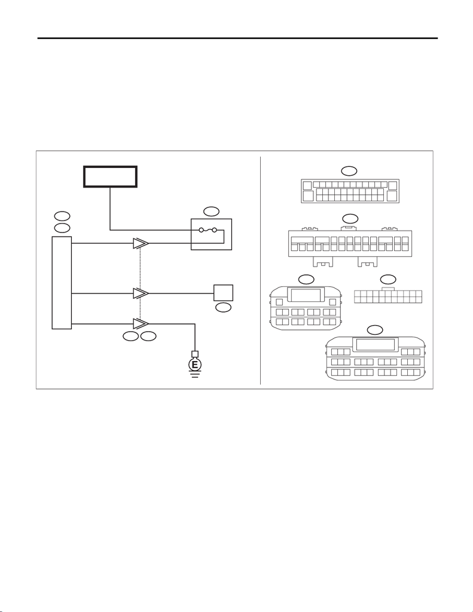

KPS(diag)-58

Diagnostic Procedure with Diagnostic Trouble Code (DTC)

KEYLESS ACCESS WITH PUSH BUTTON START SYSTEM (DIAGNOSTICS)

O: DTC B2282 VEHICLE SPEED SIGNAL ABNORMAL

DTC DETECTING CONDITION:

When the vehicle speed signal transmitted from VDC via solid line and the vehicle speed signal transmitted

from VDC via CAN communication line do not match.

CAUTION:

For replacement procedure of keyless access CM, refer to the “REGISTRATION MANUAL FOR IMMO-

BILIZER”.

WIRING DIAGRAM:

Push button start system <Ref. to WI-329, WIRING DIAGRAM, Push Button Start System.>

• Engine type: FA

2

4

13

12

17

3

16

6

15

587

14

10 11

B550

20

A11

30

B575

3412

12 13 14 15 16 17 18 19 20 21 22

589

10 11

67

3

5

B576 B575

A2

B550

10

25

B310

C27

B574C:

B572A:

B310

10 11 12 13

14

23456789

15

26

16 17 18 19 20 21 22 23 24 25

27 28 29 30 31 32 33 34 35 36 37

1

38

C: B574

123

789

22 23 24 25 26 27

10 11 12 13 14 15

28 29 30

16 17 18

19 20 21

456

63

1

45 87

2

9

1411 12 13 1615 1817

10

A: B572

SL-02776

MB-35

SBF-8

(B)

VDC CM

KEYLESS

ACCESS CM

FUSE HOLDER

7.5A

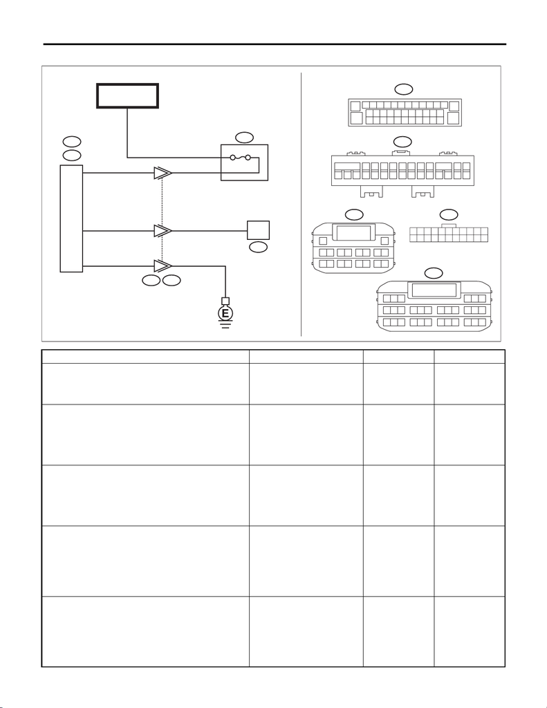

KPS(diag)-59

Diagnostic Procedure with Diagnostic Trouble Code (DTC)

KEYLESS ACCESS WITH PUSH BUTTON START SYSTEM (DIAGNOSTICS)

• Engine type: EJ

Step Check Yes No

1 CHECK LAN SYSTEM.

Inspect LAN system. <Ref. to LAN(diag)-2,

PROCEDURE, Basic Diagnostic Procedure.>

Is LAN system normal? Go to step 2. Perform the

inspection accord-

ing to the diagnosis

for LAN system.

2 CHECK COMBINATION METER.

Check that the speedometer is displayed nor-

mally.

Is the meter display normal? Go to step 3. Check the VDC.

<Ref. to

VDC(diag)-2,

PROCEDURE,

Basic Diagnostic

Procedure.>

3 CHECK CURRENT DATA.

Confirm the current data display of keyless

access system using Subaru Select Monitor.

• Vehicle speed signal

Is the parked state or driving

state displayed normally?

Go to step 4. Check the VDC.

<Ref. to

VDC(diag)-2,

PROCEDURE,

Basic Diagnostic

Procedure.>

4 CHECK FUSE.

Remove the fuse.

Is the fuse OK? Go to step 5. Replace the fuse.

When the replaced

fuse is blown

immediately, check

the power supply

circuit for short-cir-

cuited.

5 CHECK HARNESS.

1) Disconnect the keyless access CM connec-

tor.

2) Using a tester, measure the voltage

between keyless access CM connectors.

Connector & terminal

(B572) No. 2 (+) — Chassis ground (–):

Is the voltage 9.5 — 16 V? Go to step 6. Check the power

supply circuit.

5

14

13

18

432

17

7

16

698

15

11 12

B550

20

A11

30

B575

3412

12 13 14 15 16 17 18 19 20 21 22

589

10 11

67

3

5

B576 B575

A2

B550

11

26

B310

C27

B574C:

B572A:

B310

10 11 12 13

14

23456789

15

26

16 17 18 19 20 21 22 23 24 25

27 28 29 30 31 32 33 34 35 36 37

1

38

C: B574

123

789

22 23 24 25 26 27

10 11 12 13 14 15

28 29 30

16 17 18

19 20 21

456

63

1

45 87

2

9

1411 12 13 1615 1817

10

A: B572

SL-02777

MB-35

SBF-8

(B)

VDC CM

KEYLESS

ACCESS CM

FUSE HOLDER

7.5A

[figure not shown]

KPS(diag)-60

Diagnostic Procedure with Diagnostic Trouble Code (DTC)

KEYLESS ACCESS WITH PUSH BUTTON START SYSTEM (DIAGNOSTICS)

6 CHECK HARNESS.

Using a tester, measure the resistance between

the keyless access CM connector and chassis

ground.

Connector & terminal

(B572) No. 11 — Chassis ground:

Is the resistance less than 1 Ω? Go to step 7. Repair or replace

the open circuit of

harness.

7 CHECK HARNESS.

1) Disconnect the keyless access CM connec-

tor.

2) Disconnect the combination meter connec-

tor.

3) Using a tester, measure the resistance

between the keyless access CM connector and

VDC CM connector.

Connector & terminal

(B574) No. 27 — (B310) No. 30:

Is the resistance less than 1 Ω? Go to step 8. Repair or replace

the open circuit of

harness.

8 CHECK HARNESS.

Using a tester, measure the resistance between

the keyless access CM connector and chassis

ground.

Connector & terminal

(B574) No. 27 — Chassis ground:

Is the resistance 10 kΩ or

more?

Go to step 9. Repair or replace

the short circuit of

the harness.

9 CHECK KEYLESS ACCESS CM.

1) Connect each connector.

2) Using the Subaru Select Monitor, measure

the waveform between the terminals of keyless

access CM.

Connector & terminal

(B574) No. 27 — Chassis ground:

Is 3.54 Hz displayed when the

vehicle is driven approx. at 5

km/h?

Replace the key-

less access CM.

<Ref. to SL-100,

Keyless Access

CM.>

Check the VDC.

<Ref. to

VDC(diag)-2,

PROCEDURE,

Basic Diagnostic

Procedure.>

Step Check Yes No

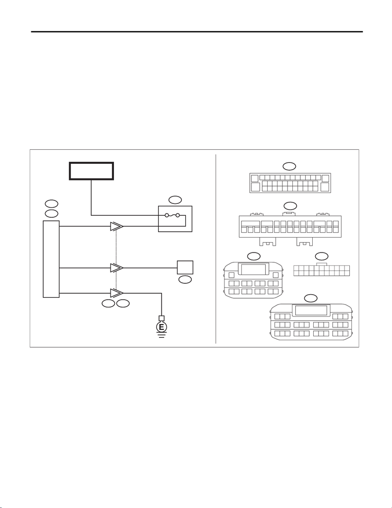

KPS(diag)-61

Diagnostic Procedure with Diagnostic Trouble Code (DTC)

KEYLESS ACCESS WITH PUSH BUTTON START SYSTEM (DIAGNOSTICS)

P: DTC B2283 VEHICLE SPEED SENSOR FAULT DETECTION

DTC DETECTING CONDITION:

Either of the following malfunctions is detected. (Vehicle speed sensor failure is detected.)

• Vehicle speed signal failure detection 1: Excessive deceleration detection

• Vehicle speed signal failure detection 2: Engine speed interlock detection

TROUBLE SYMPTOM:

The steering lock cannot be released.

CAUTION:

For replacement procedure of keyless access CM, refer to the “REGISTRATION MANUAL FOR IMMO-

BILIZER”.

WIRING DIAGRAM:

Push button start system <Ref. to WI-329, WIRING DIAGRAM, Push Button Start System.>

• Engine type: FA

2

232221 262524201918

4

13

12

17

3

16

6

15

587

14

10 11

B550

20

A11

30

B575

3412

12 13 14 15 16 17 18 19 20 21 22

589

10 11

67

3

5

B576 B575

A2

B550

10

25

B310

C27

B574C:

B572A:

B310

10 11 12 13

14

23456789

15

26

16 17 18 19 20 21 22 23 24 25

27 28 29 30 31 32 33 34 35 36 37

1

38

C: B574

123

789

22 23 24 25 26 27

10 11 12 13 14 15

28 29 30

16 17 18

19 20 21

456

63

1

45 87

2

9

1411 12 13 1615 1817

10

A: B572

SL-02776

MB-35

SBF-8

(B)

VDC CM

KEYLESS

ACCESS CM

FUSE HOLDER

7.5A

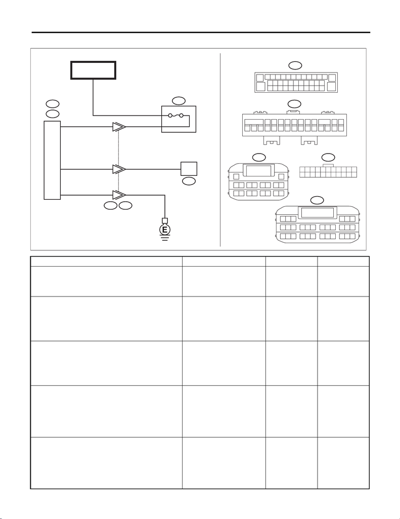

KPS(diag)-62

Diagnostic Procedure with Diagnostic Trouble Code (DTC)

KEYLESS ACCESS WITH PUSH BUTTON START SYSTEM (DIAGNOSTICS)

• Engine type: EJ

Step Check Yes No

1 CHECK LAN SYSTEM.

Inspect LAN system. <Ref. to LAN(diag)-2,

PROCEDURE, Basic Diagnostic Procedure.>

Is LAN system normal? Go to step 2. Perform the

inspection accord-

ing to the diagnosis

for LAN system.

2 CHECK COMBINATION METER.

Check that the speedometer is displayed nor-

mally.

Is the meter display normal? Go to step 3. Check the VDC.

<Ref. to

VDC(diag)-2,

PROCEDURE,

Basic Diagnostic

Procedure.>

3 CHECK CURRENT DATA.

Confirm the current data display of keyless

access system using Subaru Select Monitor.

• Vehicle speed signal

Is the parked state or driving

state displayed normally?

Go to step 4. Check the VDC.

<Ref. to

VDC(diag)-2,

PROCEDURE,

Basic Diagnostic

Procedure.>

4 CHECK FUSE.

Remove the fuse.

Is the fuse OK? Go to step 5. Replace the fuse.

When the replaced

fuse is blown

immediately, check

the power supply

circuit for short-cir-

cuited.

5 CHECK HARNESS.

1) Disconnect the keyless access CM connec-

tor.

2) Using a tester, measure the voltage

between keyless access CM connectors.

Connector & terminal

(B572) No. 2 (+) — Chassis ground (–):

Is the voltage 9.5 — 16 V? Go to step 6. Check the power

supply circuit.

242322 272625212019

5

14

13

18

432

17

7

16

698

15

11 12

B550

20

A11

30

B575

3412

12 13 14 15 16 17 18 19 20 21 22

589

10 11

67

3

5

B576 B575

A2

B550

11

26

B310

C27

B574C:

B572A:

B310

10 11 12 13

14

23456789

15

26

16 17 18 19 20 21 22 23 24 25

27 28 29 30 31 32 33 34 35 36 37

1

38

C: B574

123

789

22 23 24 25 26 27

10 11 12 13 14 15

28 29 30

16 17 18

19 20 21

456

63

1

45 87

2

9

1411 12 13 1615 1817

10

A: B572

SL-02777

MB-35

SBF-8

(B)

VDC CM

KEYLESS

ACCESS CM

FUSE HOLDER

7.5A

[figure not shown]

KPS(diag)-63

Diagnostic Procedure with Diagnostic Trouble Code (DTC)

KEYLESS ACCESS WITH PUSH BUTTON START SYSTEM (DIAGNOSTICS)

6 CHECK HARNESS.

Using a tester, measure the resistance between

the keyless access CM connector and chassis

ground.

Connector & terminal

(B572) No. 11 — Chassis ground:

Is the resistance less than 1 Ω? Go to step 7. Repair or replace

the open circuit of

harness.

7 CHECK HARNESS.

1) Disconnect the keyless access CM connec-

tor.

2) Disconnect the combination meter connec-

tor.

3) Using a tester, measure the resistance

between the keyless access CM connector and

VDC CM connector.

Connector & terminal

(B574) No. 27 — (B310) No. 30:

Is the resistance less than 1 Ω? Go to step 8. Repair or replace

the open circuit of

harness.

8 CHECK HARNESS.

Using a tester, measure the resistance between

the keyless access CM connector and chassis

ground.

Connector & terminal

(B574) No. 27 — Chassis ground:

Is the resistance 10 kΩ or

more?

Go to step 9. Repair or replace

the short circuit of

the harness.

9 CHECK KEYLESS ACCESS CM.

1) Connect each connector.

2) Using the Subaru Select Monitor, measure

the waveform between the terminals of keyless

access CM.

Connector & terminal

(B574) No. 27 — Chassis ground:

Is 3.54 Hz displayed when the

vehicle is driven approx. at 5

km/h?

Replace the key-

less access CM.

<Ref. to SL-100,

Keyless Access

CM.>

Check the VDC.

<Ref. to

VDC(diag)-2,

PROCEDURE,

Basic Diagnostic

Procedure.>

Step Check Yes No

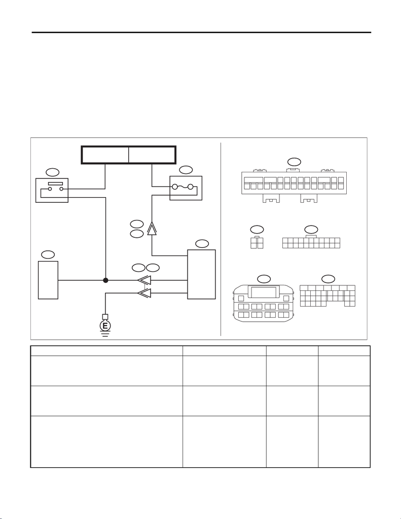

KPS(diag)-64

Diagnostic Procedure with Diagnostic Trouble Code (DTC)

KEYLESS ACCESS WITH PUSH BUTTON START SYSTEM (DIAGNOSTICS)

Q: DTC B2284 BRAKE SIGNAL (CABLE-INFORMATION DOES NOT MATCH TO

BEAN-INFORMATION)

DTC DETECTING CONDITION:

When the brake signal transmitted via solid line and the brake signal transmitted via CAN communication line

do not match.

TROUBLE SYMPTOM:

For replacement procedure of keyless access CM, refer to the “REGISTRATION MANUAL FOR IMMO-

BILIZER”.

WIRING DIAGRAM:

Stop light system <Ref. to WI-397, WIRING DIAGRAM, Stop Light System.>

Step Check Yes No

1 CHECK LAN SYSTEM.

Inspect LAN system. <Ref. to LAN(diag)-2,

PROCEDURE, Basic Diagnostic Procedure.>

Is LAN system normal? Go to step 2. Perform the

inspection accord-

ing to the diagnosis

for LAN system.

2 CHECK CURRENT DATA.

Confirm the current data display of keyless

access system using Subaru Select Monitor.

• Stop light SW

Is DTC displayed normally

according to the brake pedal

operation?

Go to step 3. Check the stop

light system.

3 CHECK CURRENT DATA.

Check the current data display of body inte-

grated unit using Subaru Select Monitor.

• Stop light SW

Is DTC displayed normally

according to the brake pedal

operation?

Go to step 4. Check body inte-

grated unit <Ref. to

BC(diag)-2, PRO-

CEDURE, Basic

Diagnostic Proce-

dure.> and the stop

light switch circuit.

B280

18

23

26

24

25

98

15

1413121110

17

16

1234567

A:

A:

91

2

4

13

12

17

3

16

6

15

587

14

10 11

B550

B65

12

34

A11

18

3

B576

B575

B575 B576

A10 A18

A2

10

25

B550

B280

B65

1

2

B575

3412

12 13 14 15 16 17 18 19 20 21 22

589

10 11

67

B572A:

63

1

45 87

2

9

10

A: B572

SL-02778

MB-35

SBF-8

(B)

FB-3

F/B FUSE NO. 8

(B)

STOP LIGHT &

BRAKE SWITCH

BODY

INTEGRATED

UNIT

FUSE HOLDER

7.5A

KEYLESS

ACCESS CM

[figure not shown]

KPS(diag)-65

Diagnostic Procedure with Diagnostic Trouble Code (DTC)

KEYLESS ACCESS WITH PUSH BUTTON START SYSTEM (DIAGNOSTICS)

4 CHECK FUSE.

Check the fuse.

Is the fuse OK? Go to step 5. Replace the fuse.

When the replaced

fuse is blown

immediately, check

the power supply

circuit for short-cir-

cuited.

5 CHECK HARNESS.

1) Disconnect the keyless access CM connec-

tor.

2) Using a tester, measure the voltage

between keyless access CM connectors.

Connector & terminal

(B572) No. 2 (+) — Chassis ground (–):

Is the voltage 9.5 — 16 V? Go to step 6. Check the power

supply circuit.

6 CHECK HARNESS.

Using a tester, measure the resistance between

the keyless access CM connector and chassis

ground.

Connector & terminal

(B572) No. 11 — Chassis ground:

Is the resistance less than 1 Ω? Go to step 7. Repair or replace

the open circuit of

harness.

7 CHECK HARNESS.

1) Disconnect the stop light switch connector.

2) Using a tester, measure the resistance

between the keyless access CM connector and

stop light switch connector.

Connector & terminal

(B572) No. 18 — (B65) No. 2:

Is the resistance less than 1 Ω? Go to step 8. Repair or replace

the open circuit of

harness.

8 CHECK HARNESS.

Using a tester, measure the resistance between

the keyless access CM connector and chassis

ground.

Connector & terminal

(B572) No. 18 — Chassis ground:

Is the resistance 10 kΩ or

more?

Go to step 9. Repair or replace

the short circuit of

the harness.

9 CHECK HARNESS.

Using a tester, measure the voltage between

the keyless access CM connector and chassis

ground when the brake pedal is depressed.

Connector & terminal

(B572) No. 18 (+) — Chassis ground (–):

Does the voltage change as fol-

lows? Brake pedal not

depressed: 1 V or less → Brake

pedal depressed: 11 — 14 V

Replace the key-

less access CM.

<Ref. to SL-100,

REMOVAL, Key-

less Access CM.>

Check the power

supply circuit of

stop light switch.

Step Check Yes No

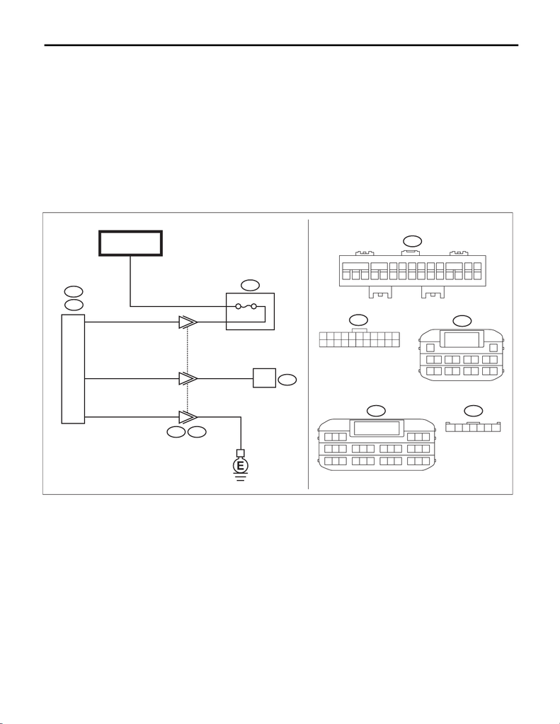

KPS(diag)-66

Diagnostic Procedure with Diagnostic Trouble Code (DTC)

KEYLESS ACCESS WITH PUSH BUTTON START SYSTEM (DIAGNOSTICS)

R: DTC B2285 STEERING LOCK POSITION SIGNAL ABNORMAL

DTC DETECTING CONDITION:

When the steering lock position signal transmitted from the steering lock CM via solid line and the steering

lock position signal transmitted via LIN communication system do not match.

TROUBLE SYMPTOM:

• There are conditions when the steering lock is not released.

• Engine will not start.

CAUTION:

For replacement procedure of keyless access CM, refer to the “REGISTRATION MANUAL FOR IMMO-

BILIZER”.

WIRING DIAGRAM:

Push button start system <Ref. to WI-329, WIRING DIAGRAM, Push Button Start System.>

• Engine type: FA

2

232221 262524201918

4

13

12

17

3

16

6

15

587

14

10 11

B550

20

3

15

B576 B575

A11

4

A2

B550

10

52

B424

C26

B572A:

B424

12345

6

7

3412

12 13 14 15 16 17 18 19 20 21 22

589

10 11

67

B575

B574C:

C: B574

123

789

22 23 24 25 26 27

10 11 12 13 14 15

28 29 30

16 17 18

19 20 21

456

63

1

45 87

2

9

1411 12 13 1615 1817

10

A: B572

SL-02779

MB-35

SBF-8

(B)

STEERING

LOCK CM

KEYLESS

ACCESS CM

FUSE HOLDER

7.5A

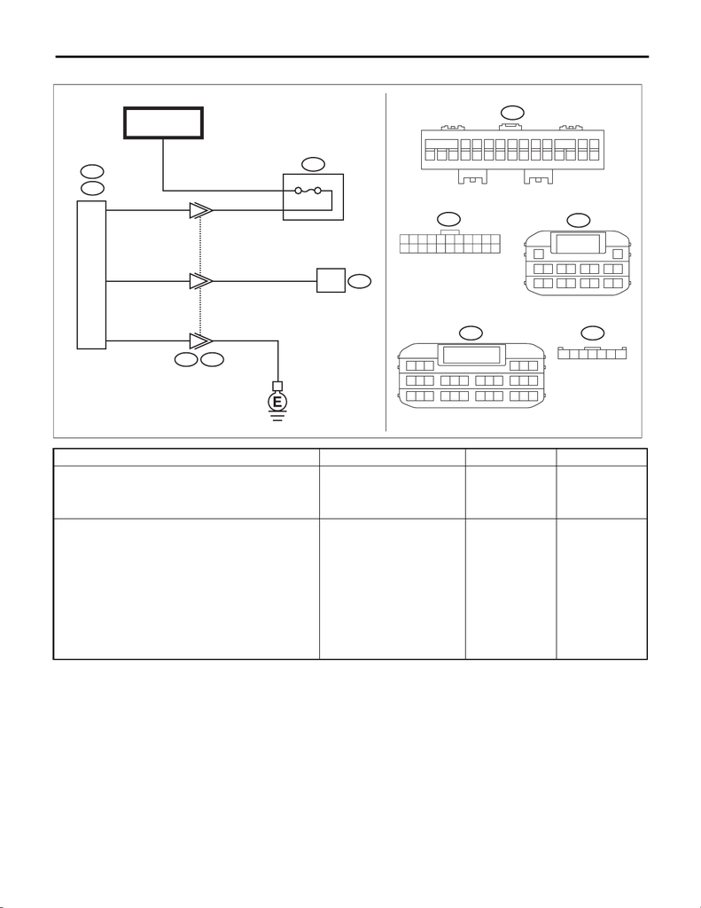

KPS(diag)-67

Diagnostic Procedure with Diagnostic Trouble Code (DTC)

KEYLESS ACCESS WITH PUSH BUTTON START SYSTEM (DIAGNOSTICS)

Step Check Yes No

1 CHECK LAN SYSTEM.

Inspect LAN system. <Ref. to LAN(diag)-2,

PROCEDURE, Basic Diagnostic Procedure.>

Is LAN system normal? Go to step 2. Perform the

inspection accord-

ing to the diagnosis

for LAN system.

2 CHECK DTC.

Use the Subaru Select Monitor and read DTCs.

Is B2785 displayed? Perform the

inspection accord-

ing to B2785. <Ref.

to KPS(diag)-77,

DTC B2785 LIN

COMMUNICA-

TION ERROR,

Diagnostic Proce-

dure with Diagnos-

tic Trouble Code

(DTC).>

Go to step 3.

242322 272625212019

5

14

13

18

432

17

7

16

698

15

11 12

B550

20

3

15

B576 B575

A11

4

A2

B550

11

62

B424

C26

B572A:

B424

12345

6

7

3412

12 13 14 15 16 17 18 19 20 21 22

589

10 11

67

B575

B574C:

C: B574

123

789

22 23 24 25 26 27

10 11 12 13 14 15

28 29 30

16 17 18

19 20 21

456

63

1

45 87

2

9

1411 12 13 1615 1817

10

A: B572

SL-02780

MB-35

SBF-8

(B)

STEERING

LOCK CM

KEYLESS

ACCESS CM

FUSE HOLDER

7.5A

[figure not shown]

KPS(diag)-68

Diagnostic Procedure with Diagnostic Trouble Code (DTC)

KEYLESS ACCESS WITH PUSH BUTTON START SYSTEM (DIAGNOSTICS)

3 CHECK CURRENT DATA.

Confirm the current data display of keyless

access system using Subaru Select Monitor.

When locked:

• Lock side sensor status: ON

• Unlock side sensor status: OFF

• Lock confirmation: Confirmed

• Unlock confirmation: Not confirmed

When unlocked:

• Lock side sensor status: OFF

• Unlock side sensor status: ON

• Lock confirmation: Not confirmed

• Unlock confirmation: Confirmed

NOTE:

To lock the steering lock, turn off the power, and

open → close, or close → open the driver’s

door. To unlock the steering lock, turn the igni-

tion switch to ACC ON or IGN ON.

Are the readings as shown on

the left according to the steer-

ing lock status?

Go to step 4. Replace the steer-

ing lock CM. <Ref.

to SL-104,

REMOVAL, Steer-

ing Lock CM.>

4 CHECK CURRENT DATA.

Confirm the current data display of keyless

access system using Subaru Select Monitor.

When locked:

• Steering unlock switch: OFF

When unlocked:

• Steering unlock switch: ON

NOTE:

To lock the steering lock, turn off the power, and

open → close, or close → open the driver’s

door. To unlock the steering lock, turn the igni-

tion switch to ACC ON or IGN ON.

Are the readings as shown on

the left according to the steer-

ing lock status?

Replace the key-

less access CM.

<Ref. to SL-100,

REMOVAL, Key-

less Access CM.>

Go to step 5.

5 CHECK FUSE.

Check the fuse.

Is the fuse OK? Go to step 6. Replace the fuse.

When the replaced

fuse is blown

immediately, check

the power supply

circuit for short-cir-

cuited.

6 CHECK HARNESS.

1) Disconnect the keyless access CM connec-

tor.

2) Using a tester, measure the voltage

between keyless access CM connectors.

Connector & terminal

(B572) No. 2 (+) — Chassis ground (–):

Is the voltage 9.5 — 16 V? Go to step 7. Check the power

supply circuit.

7 CHECK HARNESS.

Using a tester, measure the resistance between

the keyless access CM connector and chassis

ground.

Connector & terminal

(B572) No. 11 — Chassis ground:

Is the resistance less than 1 Ω? Go to step 8. Repair or replace

the open circuit of

harness.

8 CHECK HARNESS.

Using a tester, measure the resistance between

the steering lock CM connector and chassis

ground.

Connector & terminal

(B424) No. 4 — Chassis ground:

Does the following occur?

Steering lock: 10 kΩ or more →

Steering unlock: less than 1 Ω

Go to step 9

. Replace the steer-

ing lock CM. <Ref.

to SL-104,

REMOVAL, Steer-

ing Lock CM.>

Step Check Yes No

[figure not shown]

Diagnostic Procedure with Diagnostic Trouble Code (DTC)

KEYLESS ACCESS WITH PUSH BUTTON START SYSTEM (DIAGNOSTICS)

9 CHECK HARNESS.

1) Disconnect the keyless access CM connec-

tor.

2) Disconnect the steering lock CM connector.

3) Using a tester, measure the resistance

between the keyless access CM connector and

steering lock CM.

Connector & terminal

(B574) No. 26 — (B424) No. 4:

Is the resistance less than 1 Ω? Go to step 10. Repair or replace

the open circuit of

harness.

10 CHECK HARNESS.

Using a tester, measure the resistance between

the keyless access CM connector and chassis

ground.

Connector & terminal

(B574) No. 26 — Chassis ground:

Is the resistance 10 kΩ or

more?

Replace the key-

less access CM.

<Ref. to SL-100,

REMOVAL, Key-

less Access CM.>

Repair or replace

the short circuit of

the harness.

Step Check Yes No

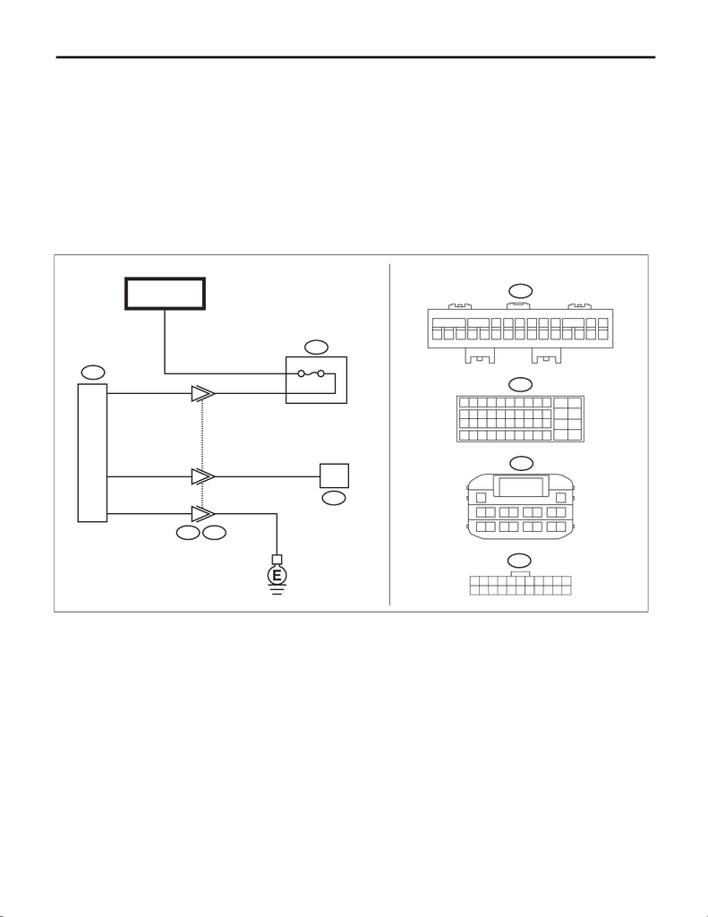

Diagnostic Procedure with Diagnostic Trouble Code (DTC)

KEYLESS ACCESS WITH PUSH BUTTON START SYSTEM (DIAGNOSTICS)

S: DTC B2286 DRIVING POSSIBLE SIGNAL ABNORMAL

DTC DETECTING CONDITION:

When the engine speed signal transmitted from the ECM via solid line and the engine speed signal transmit-

ted from the ECM via CAN communication line do not match.

TROUBLE SYMPTOM:

Cannot start the engine, or the engine stops after starting.

CAUTION:

For replacement procedure of keyless access CM, refer to the “REGISTRATION MANUAL FOR IMMO-

BILIZER”.

WIRING DIAGRAM:

Push button start system <Ref. to WI-329, WIRING DIAGRAM, Push Button Start System.>

• Engine type: FA

91

2

4

13

12

17

3

16

6

15

587

14

10 11

B550

20

3

7

B576 B575

10

11 12

23 24

35 36

47 48

3

5

6

7894

12

45

21

33

B134A:

A:

B134

B575

3412

12 13 14 15 16 17 18 19 20 21 22

589

10 11

67

A11

A4

A2

B550

10

25

A17

B572A:

63

1

45 87

2

9

10

A: B572

SL-02781

ECM

MB-35

SBF-8

(B)

KEYLESS

ACCESS CM

FUSE HOLDER

7.5A

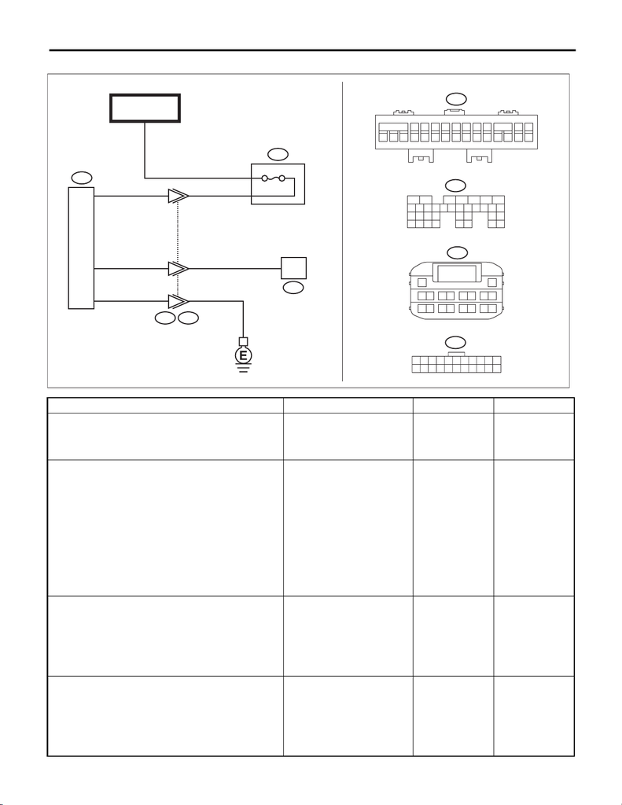

Diagnostic Procedure with Diagnostic Trouble Code (DTC)

KEYLESS ACCESS WITH PUSH BUTTON START SYSTEM (DIAGNOSTICS)

• Engine type: EJ

Step Check Yes No

1 CHECK LAN SYSTEM.

Inspect LAN system. <Ref. to LAN(diag)-2,

PROCEDURE, Basic Diagnostic Procedure.>

Is LAN system normal? Go to step 2. Perform the

inspection accord-

ing to the diagnosis

for LAN system.

2 CHECK CURRENT DATA.

Confirm the current data display of keyless

access system using Subaru Select Monitor.

• Engine speed

Can the data be read normally? Perform the diag-

nosis for the

engine. <Ref. to

EN(w/o STI)(diag)-

66, Diagnostics for

Engine Starting

Failure.> <Ref. to

EN(STI)(diag)-67,

PROCEDURE,

Diagnostics for

Engine Starting

Failure.>

Go to step 3.

3 CHECK FUSE.

Remove the fuse.

Is the fuse OK? Go to step 4. Replace the fuse.

When the replaced

fuse is blown

immediately, check

the power supply

circuit for short-cir-

cuited.

4 CHECK HARNESS.

1) Disconnect the keyless access CM connec-

tor.

2) Using a tester, measure the voltage

between keyless access CM connectors.

Connector & terminal

(B572) No. 2 (+) — Chassis ground (–):

Is the voltage 9.5 — 16 V? Go to step 5. Check the power

supply circuit.

B135B:

29

10 11 12 13 14 15

2524

16

30

98

17 18 19

20

28

21 22 23

3231

26 27

33 34 35

101

5

14

13

18

432

17

7

16

698

15

11 12

B550

20

3

7

B576 B575

B:

B135

B575

3412

12 13 14 15 16 17 18 19 20 21 22

589

10 11

67

A11

B15

A2

B550

11

26

A17

B572A:

63

1

45 87

2

9

10

A: B572

SL-02782

MB-35

SBF-8

(B)

ECM

KEYLESS

ACCESS CM

FUSE HOLDER

7.5A

[figure not shown]

KPS(diag)-72

Diagnostic Procedure with Diagnostic Trouble Code (DTC)

KEYLESS ACCESS WITH PUSH BUTTON START SYSTEM (DIAGNOSTICS)

5 CHECK HARNESS.

Using a tester, measure the resistance between

the keyless access CM connector and chassis

ground.

Connector & terminal

(B572) No. 11 — Chassis ground:

Is the resistance less than 1 Ω? Go to step 6. Repair or replace

the open circuit of

harness.

6 CHECK HARNESS.

1) Disconnect the keyless access CM connec-

tor.

2) Disconnect the ECM connector.

3) Using a tester, measure the resistance

between the keyless access CM connector and

ECM connector.

Connector & terminal

Engine type: FA

(B572) No. 17 — (B134) No. 4:

Engine type: EJ

(B572) No. 17 — (B135) No. 15:

Is the resistance less than 1 Ω? Go to step 7. Repair or replace

the open circuit of

harness.

7 CHECK HARNESS.

Using a tester, measure the resistance between

the keyless access CM connector and chassis

ground.

Connector & terminal

(B572) No. 17 — Chassis ground:

Is the resistance 10 kΩ or

more?

Go to step 8. Repair or replace

harness.

8 CHECK HARNESS.

1) Connect the keyless access CM connector

and ECM connector.

2) Using the Subaru Select Monitor, measure

the waveform between the keyless access CM

connector and chassis ground.

Connector & terminal

(B572) No. 17 — Chassis ground:

Does the pulse stop when the

engine is stopped, and does

the pulse generate when the

engine is started?

Replace the key-

less access CM.

<Ref. to SL-100,

Keyless Access

CM.>

Perform the diag-

nosis for the

engine. <Ref. to

EN(w/o STI)(diag)-

66, Diagnostics for

Engine Starting

Failure.> <Ref. to

EN(STI)(diag)-67,

PROCEDURE,

Diagnostics for

Engine Starting

Failure.>

Step Check Yes No

[figure not shown]

KPS(diag)-73

Diagnostic Procedure with Diagnostic Trouble Code (DTC)

KEYLESS ACCESS WITH PUSH BUTTON START SYSTEM (DIAGNOSTICS)

T: DTC B2779 REMOTE CONTROL ENGINE STARTER COMMUNICATION COL-

LATION NG

DTC DETECTING CONDITION:

When the keyless access CM does not respond to engine start even when the remote control engine starter

is ON, or when there is a code mismatch.

TROUBLE SYMPTOM:

Remote engine starter does not function.

U: DTC B2781 STEERING LOCK ECU OPEN/SHORT

DTC DETECTING CONDITION:

• When malfunction is detected in lock/unlock position detection sensor.

• When the open or short circuit in the steering lock motor drive circuit is detected.

TROUBLE SYMPTOM:

• The steering lock cannot be released.

• Engine will not start.

CAUTION:

For replacement procedure of steering lock CM, refer to the “REGISTRATION MANUAL FOR IMMO-

BILIZER”.

NOTE:

When all ECMs connected to collation system LIN bus cannot communicate with the keyless access CM,

DTC B2785 is output.

Step Check Yes No

1 REGISTER THE REMOTE ENGINE START-

ER.

1) Clear the DTC.

2) Register the remote engine starter using the

Subaru Select Monitor. (Refer to the “REGIS-

TRATION MANUAL FOR IMMOBILIZER”.)

3) Read the DTC again.

Is DTC B2779 detected? Replace the

remote engine

starter.

System is normal.

It is possible that

temporary poor

contact occurs.

Step Check Yes No

1 CHECK DTC.

Use the Subaru Select Monitor and read DTCs.

Is B2785 displayed? Perform the diag-

nosis according to

DTC.

Replace the steer-

ing lock CM. <Ref.

to SL-104, Steer-

ing Lock CM.>

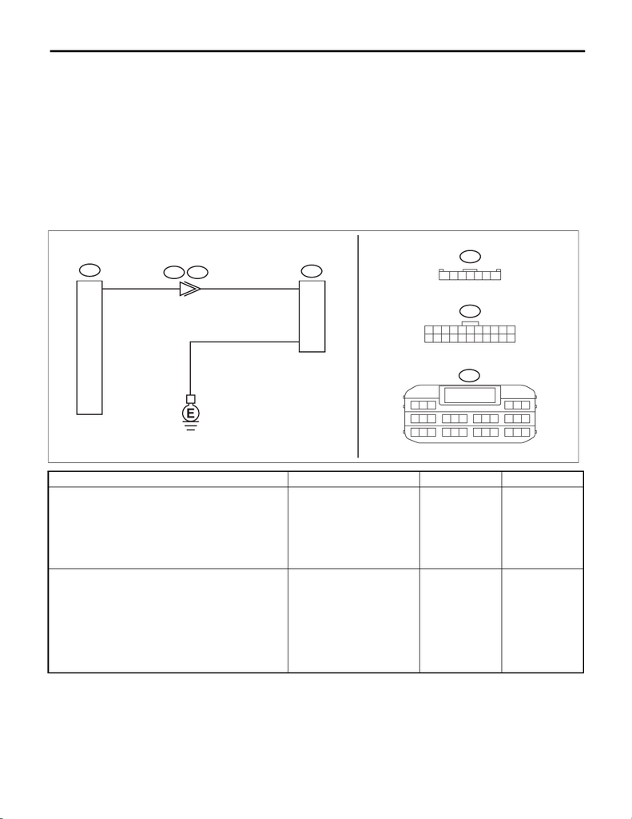

KPS(diag)-74

Diagnostic Procedure with Diagnostic Trouble Code (DTC)

KEYLESS ACCESS WITH PUSH BUTTON START SYSTEM (DIAGNOSTICS)

V: DTC B2782 STEERING LOCK POWER SUPPLY CIRCUIT ABNORMAL

(SMART ECU-SIDE ABNORMAL)

DTC DETECTING CONDITION:

When the open or short circuit in the steering lock motor power supply circuit is detected.

TROUBLE SYMPTOM:

• The steering lock cannot be released.

• Engine will not start.

CAUTION:

For replacement procedure of keyless access CM and steering lock CM, refer to the “REGISTRATION

MANUAL FOR IMMOBILIZER”.

WIRING DIAGRAM:

Push button start system <Ref. to WI-329, WIRING DIAGRAM, Push Button Start System.>

Step Check Yes No

1 CHECK STEERING LOCK CM.

1) Disconnect the steering lock CM connector.

2) Using a tester, measure the resistance

between the steering lock CM connector and

chassis ground.

Connector & terminal

(B424) No. 1 — Chassis ground:

Is the resistance less than 1 Ω? Go to step 2. Repair or replace

the open circuit of

harness.

2 CHECK CURRENT DATA.

1) Connect the steering lock CM connector.

2) ACC OFF, IGN OFF, shift position in P

3) Using a tester, open the door, and measure

the voltage between terminals of steering CM

connector when the steering lock motor is

driven.

Connector & terminal

(B424) No. 3 (+) — (B424) No. 1 (–):

Does the voltage change as fol-

lows? Steering lock motor in

operation: 1 V or less → Steer-

ing lock motor is stopped: 11 —

14 V

Go to step 3. Go to step 4.

B575

123

456789

10 11

6

B576 B575

B424

12345

6

7

C: B574

123

789

22 23 24 25 26 27

10 11 12 13 14 15

28 29 30

16 17 18

19 20 21

456

B424

1

C: B574

3C29

SL-02783

KEYLESS

ACCESS CM

STEERING

LOCK CM

[figure not shown]

KPS(diag)-75

Diagnostic Procedure with Diagnostic Trouble Code (DTC)

KEYLESS ACCESS WITH PUSH BUTTON START SYSTEM (DIAGNOSTICS)

3 CHECK DTC.

1) Turn the ignition switch to ON.

2) Using the Subaru Select Monitor, clear the

memory.

3) Turn the ignition switch to OFF.

4) Disconnect the battery ground cable and

reconnect it, and then clear the abnormal infor-

mation displayed on the data monitor.

5) Turn the ignition switch to ON.

6) Use the Subaru Select Monitor and read

DTCs.

Is B2782 displayed? Replace the steer-

ing lock CM. <Ref.

to SL-104, Steer-

ing Lock CM.>

System is normal.

It is possible that

temporary poor

contact occurs.

4 CHECK CONNECTOR.

1) Disconnect the steering lock CM connector.

2) Disconnect the keyless access CM connec-

tor.

Are connectors normal? Go to step 5. Repair or replace

the connector.

5 CHECK HARNESS.

Using a tester, measure the resistance between

steering lock CM connector and keyless access

CM connector.

Connector & terminal

(B574) No. 29 — (B424) No. 3:

Is the resistance less than 1 Ω? Go to step 6. Repair or replace

the open circuit of

harness.

6 CHECK HARNESS.

Using a tester, measure the resistance between

steering lock CM connector and chassis

ground, and between keyless access CM con-

nector and chassis ground.

Connector & terminal

(B424) No. 3 — Chassis ground:

(B574) No. 29 — Chassis ground:

Is the resistance 10 kΩ or

more?

Replace the key-

less access CM.

<Ref. to SL-100,

Keyless Access

CM.>

Repair or replace

the short circuit of

the harness.

Step Check Yes No

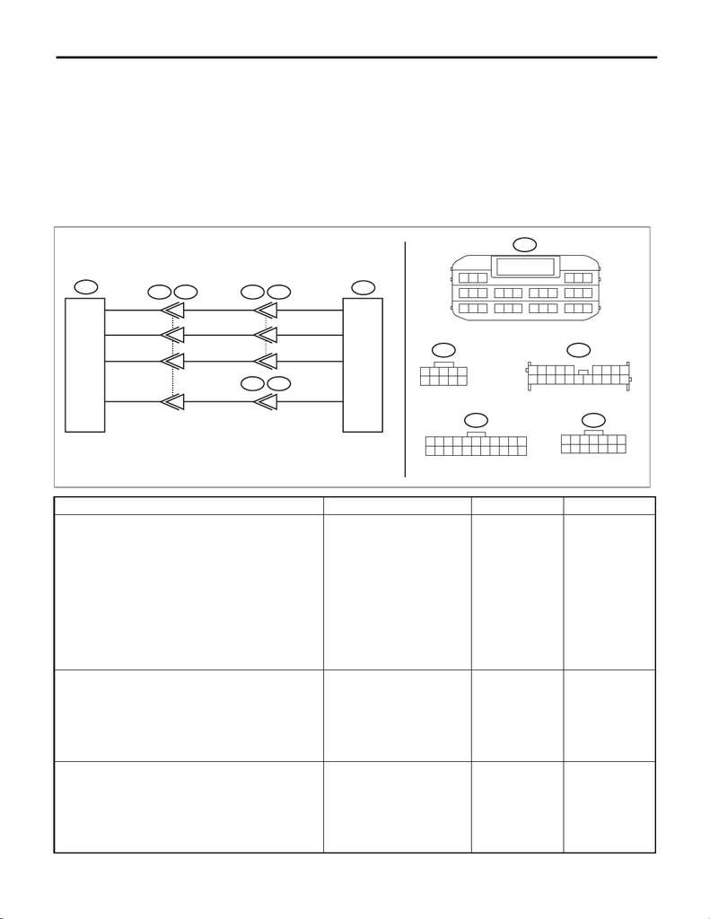

KPS(diag)-76

Diagnostic Procedure with Diagnostic Trouble Code (DTC)

KEYLESS ACCESS WITH PUSH BUTTON START SYSTEM (DIAGNOSTICS)

W: DTC B2784 ANTENNA COIL FAULT

DTC DETECTING CONDITION:

When open or short circuit occurs in the antenna coil.

TROUBLE SYMPTOM:

The keyless access function may not be operable.

CAUTION:

For replacement procedure of keyless access CM and steering lock CM, refer to the “REGISTRATION

MANUAL FOR IMMOBILIZER”.

WIRING DIAGRAM:

Immobilizer system <Ref. to WI-259, WIRING DIAGRAM, Immobilizer System.>

Step Check Yes No

1 CHECK STEERING LOCK CM.

1) Disconnect the push button ignition switch

connector.

2) Disconnect the keyless access CM connec-

tor.

3) Using the tester, measure the resistance

between terminals.

Connector & terminal

(i150) No. 14 — (B574) No. 1:

(i150) No. 9 — (B574) No. 9:

(i150) No. 10 — (B574) No. 7:

(i150) No. 8 — (B574) No. 24:

Is the resistance less than 1 Ω? Go to step 2. Repair or replace

the open circuit of

harness.

2 CHECK HARNESS.

Using the tester, measure the resistance

between terminals.

Connector & terminal

(i150) No. 14 — Chassis ground:

(i150) No. 9 — Chassis ground:

(i150) No. 10 — Chassis ground:

Is the resistance 10 kΩ or

more?

Go to step 3. Repair or replace

the short circuit of

the harness.

3 CHECK PUSH BUTTON IGNITION SWITCH.

1) Replace the push button ignition switch.

<Ref. to SL-106, Push Button Ignition Switch.>

2) Using the Subaru Select Monitor, clear the

memory.

3) Use the Subaru Select Monitor and read

DTCs.

Is B2784 displayed? Replace the key-

less access CM.

<Ref. to SL-100,

Keyless Access

CM.>

Malfunction

occurred in the

push button igni-

tion switch.

10

12345

6789

B23

12345 6789

i231

i150

1234567

89

10 11 12 13 14

213

456789

10 11

B575

B576B575

B28B23

14

9

4

8

B553i231

15

18

16

17

C: B574

C24

8

C1

14

C7

10

C9

9

i150

C: B574

123

789

22 23 24 25 26 27

10 11 12 13 14 15

28 29 30

16 17 18

19 20 21

456

SL-02784

PUSH BUTTON

IGNITION SWITCH

KEYLESS

ACCESS CM

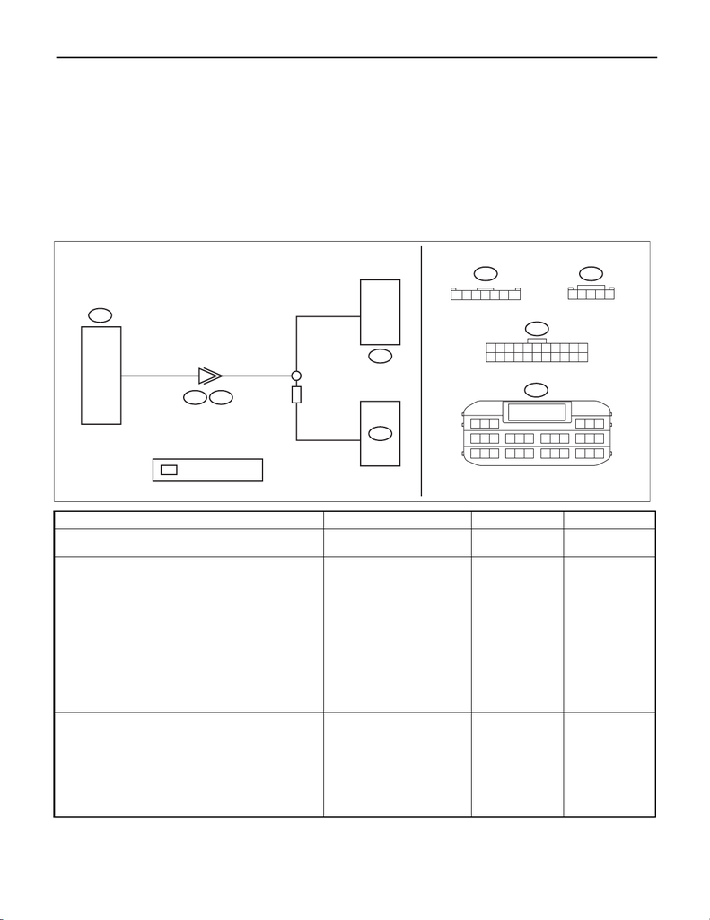

KPS(diag)-77

Diagnostic Procedure with Diagnostic Trouble Code (DTC)

KEYLESS ACCESS WITH PUSH BUTTON START SYSTEM (DIAGNOSTICS)

X: DTC B2785 LIN COMMUNICATION ERROR

DTC DETECTING CONDITION:

When the keyless access CM detected the collation system LIN bus communication error three times in a

row.

TROUBLE SYMPTOM:

The keyless access function may not be operable.

CAUTION:

For replacement procedure of keyless access CM and steering lock CM, refer to the “REGISTRATION

MANUAL FOR IMMOBILIZER”.

WIRING DIAGRAM:

Push button start system <Ref. to WI-329, WIRING DIAGRAM, Push Button Start System.>

Step Check Yes No

1 CHECK DTC.

Use the Subaru Select Monitor and read DTCs.

Is B2785 displayed? Go to step 2. Check the connec-

tor.

2 CHECK HARNESS.

1) Disconnect the keyless access CM connec-

tor.

2) Disconnect the steering lock CM connector.

3) Disconnect the ID code box connector. (with

ID code box)

4) Using the tester, measure the resistance

between terminals.

Connector & terminal

(B574) No. 17 — (B424) No. 5:

(B574) No. 17 — (B422) No. 2: (With ID

code box)

Is the resistance less than 1 Ω? Go to step 3. Repair or replace

the open circuit of

harness.

3 CHECK HARNESS.

Using the tester, measure the resistance

between terminals.

Connector & terminal

(B424) No. 5 — Chassis ground:

(B574) No. 17 — Chassis ground:

(B422) No. 5 — Chassis ground: (with ID

code box)

Is the resistance 10 kΩ or

more?

Go to step 4. Repair or replace

the short circuit of

the harness.

B422

1

2

345

ID

ID

2

B576 B575

B574C:

2

B422

5

C17

B424

B424

12345

6

7

654

212019

181716

302928

272625242322

987

321

47B5C

3412

12 13 14 15 16 17 18 19 20 21 22

589

10 11

67

B575

SL-02785

:

STEERING

LOCK CM

KEYLESS

ACCESS CM

ID CODE BOX

: WITH ID CODE BOX

[figure not shown]

KPS(diag)-78

Diagnostic Procedure with Diagnostic Trouble Code (DTC)

KEYLESS ACCESS WITH PUSH BUTTON START SYSTEM (DIAGNOSTICS)

4 CHECK HARNESS.

1) Connect the keyless access CM connector

only.

2) Use the Subaru Select Monitor and read

DTCs.

Is B2785 displayed? Replace the key-

less access CM.

<Ref. to SL-100,

Keyless Access

CM.>

Go to step 5.

5 CHECK ID CODE BOX.

NOTE:

For model without ID code box, go to the next

step.

1) Connect only the ID code box.

2) Use the Subaru Select Monitor and read

DTCs.

Is B2785 displayed? Replace the ID

code box.

Go to step 6.

6 CHECK STEERING LOCK CM.

1) Replace the steering lock CM, and then

connect it. <Ref. to SL-104, Steering Lock CM.>

2) Using the Subaru Select Monitor, clear the

memory.

3) Use the Subaru Select Monitor and read

DTCs.

Is B2785 displayed? Replace the key-

less access CM.

<Ref. to SL-100,

Keyless Access

CM.>

Malfunction

occurred in the

steering lock CM.

Step Check Yes No

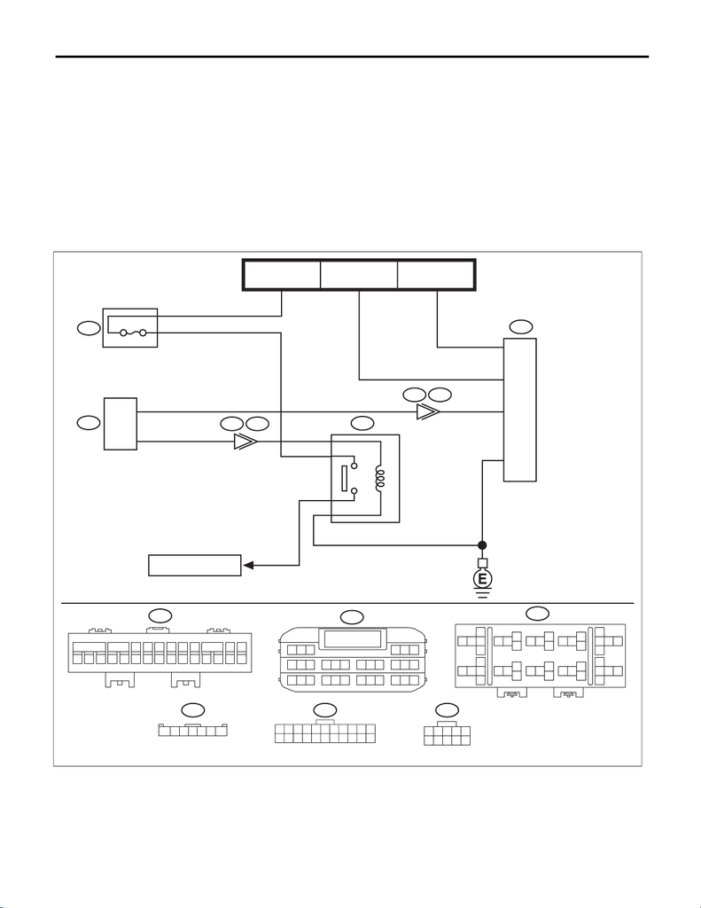

KPS(diag)-79

Diagnostic Procedure with Diagnostic Trouble Code (DTC)

KEYLESS ACCESS WITH PUSH BUTTON START SYSTEM (DIAGNOSTICS)

Y: DTC B2786 NO RESPONSE FROM STEERING LOCK ECU

DTC DETECTING CONDITION:

When communication between keyless access CM and steering lock CM is interrupted for a set amount of

time.

TROUBLE SYMPTOM:

The steering lock cannot be released.

CAUTION:

For replacement procedure of keyless access CM and steering lock CM, refer to the “REGISTRATION

MANUAL FOR IMMOBILIZER”.

WIRING DIAGRAM:

Push button start system <Ref. to WI-329, WIRING DIAGRAM, Push Button Start System.>

• Engine type: FA

B23

10

12345

6789

91

2

4

13

12

17

3

16

6

15

587

14

10 11

B550

2

3

B28 B23

B576 B575

39

36

37

38

B225

9

23

B550

20A

6

5

1

7

B424

B424

12345

6

7

B575

3412

12 13 14 15 16 17 18 19 20 21 22

589

10 11

67

C17

C6

C: B574

B225

10 11

12

13

14 15

16

18

19 21 22

20

17

24

5

3

17

9

8

6

32 33

34

35

25

27

29

30

31

36 37

38

40

41 43 44

42

39

C: B574

123

789

22 23 24 25 26 27

10 11 12 13 14 15

28 29 30

16 17 18

19 20 21

456

SL-02929

MB-31

SBF-6

(B)

REF. TO POWER SUPPLY

CIRCUIT

FB-43

F/B FUSE NO. 32

(IG)

FB-18

F/B FUSE NO. 7

(B)

STEERING

LOCK CM

KEYLESS

ACCESS CM

FUSE HOLDER

IG RELAY 1

(PUSH BUTTON START)

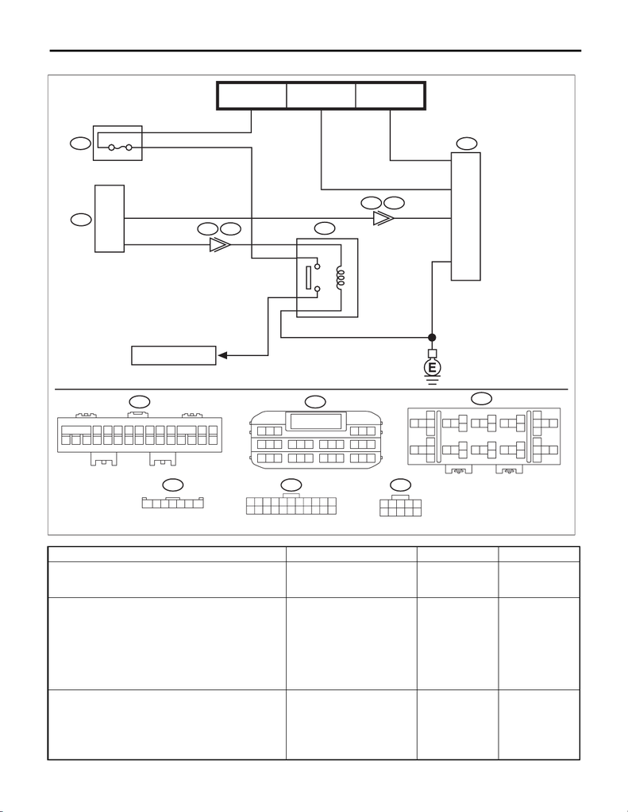

KPS(diag)-80

Diagnostic Procedure with Diagnostic Trouble Code (DTC)

KEYLESS ACCESS WITH PUSH BUTTON START SYSTEM (DIAGNOSTICS)

• Engine type: EJ

Step Check Yes No

1 CHECK DTC.

Use the Subaru Select Monitor and read DTCs.

Is a DTC other than B2786 dis-

played?

Perform the diag-

nosis according to

DTC.

Go to step 2.

2 CHECK HARNESS.

1) Disconnect the keyless access CM connec-

tor.

2) Disconnect the steering lock CM connector.

3) Using the tester, measure the resistance

between terminals.

Connector & terminal

(B574) No. 17 — (B424) No. 5:

Is the resistance less than 1 Ω? Go to step 3. Repair or replace

the open circuit of

harness.

3 CHECK HARNESS.

Using the tester, measure the resistance

between terminals.

Connector & terminal

(B424) No. 5 — Chassis ground:

(B574) No. 17 — Chassis ground:

Is the resistance 10 kΩ or

more?

Go to step 4. Repair or replace

the short circuit of

the harness.

101

5

14

13

18

432

17

7

16

698

15

11 12

B550

B23

10

12345

6789

2

3

B28 B23

B576 B575

39

36

37

38

B225

10

24

B550

20A

6

5

1

7

B424

B424

12345

6

7

B575

3412

12 13 14 15 16 17 18 19 20 21 22

589

10 11

67

C17

C6

C: B574

B225

10 11

12

13

14 15

16

18

19 21 22

20

17

24

5

3

17

9

8

6

32 33

34

35

25

27

29

30

31

36 37

38

40

41 43 44

42

39

C: B574

123

789

22 23 24 25 26 27

10 11 12 13 14 15

28 29 30

16 17 18

19 20 21

456

SL-02930

MB-31

SBF-6

(B)

REF. TO POWER SUPPLY

CIRCUIT

FB-43

F/B FUSE NO. 32

(IG)

FB-18

F/B FUSE NO. 7

(B)

STEERING

LOCK CM

KEYLESS

ACCESS CM

FUSE HOLDER

IG RELAY 1

(PUSH BUTTON START)

[figure not shown]

KPS(diag)-81

Diagnostic Procedure with Diagnostic Trouble Code (DTC)

KEYLESS ACCESS WITH PUSH BUTTON START SYSTEM (DIAGNOSTICS)

4 CHECK HARNESS.

Using a tester, measure the resistance between

the steering lock CM connector and chassis

ground.

Connector & terminal

(B424) No. 1 — Chassis ground:

Is the resistance less than 1 Ω? Go to step 5. Repair or replace

the open circuit of

harness.

5 CHECK HARNESS.

1) Turn the ignition switch to ON.

2) Using a tester, measure the voltage

between the steering lock CM connector and

chassis ground.

Connector & terminal

(B424) No. 6 (+) — Chassis ground (–):

(B424) No. 7 (+) — Chassis ground (–):

Is the voltage 11 — 14 V? Go to step 6. Repair or replace

the open circuit of

harness.

6 CHECK STEERING LOCK CM.

1) Turn the ignition switch to ON.

2) Replace the steering lock CM. <Ref. to SL-

104, Steering Lock CM.>

3) Using the Subaru Select Monitor, clear the

memory.

4) Use the Subaru Select Monitor and read

DTCs.

Is B2786 displayed? Replace the key-

less access CM.

<Ref. to SL-100,

Keyless Access

CM.>

Malfunction

occurred in the

steering lock CM.

Step Check Yes No

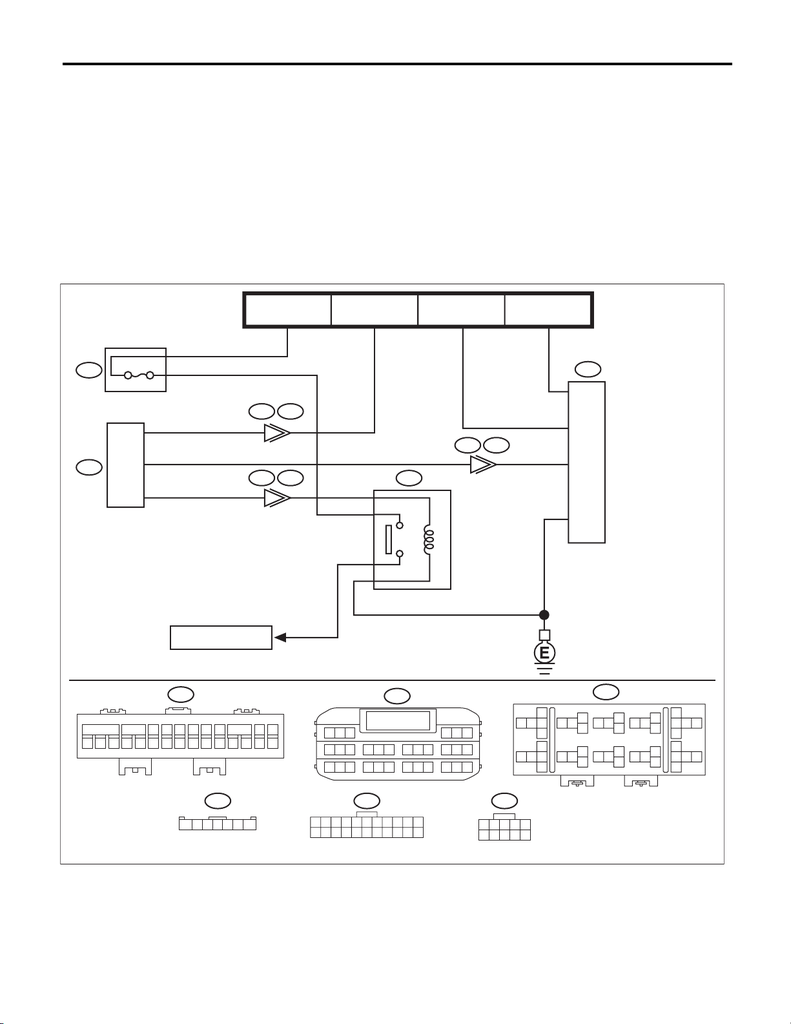

KPS(diag)-82

Diagnostic Procedure with Diagnostic Trouble Code (DTC)

KEYLESS ACCESS WITH PUSH BUTTON START SYSTEM (DIAGNOSTICS)

Z: DTC B2788 IGN1 INPUT ABNORMAL

DTC DETECTING CONDITION:

When mismatch occurs in the IG1 input of the steering lock CM for both LIN communication line input (IG1

input value of keyless access CM) and solid line input.

TROUBLE SYMPTOM:

The steering lock cannot be released.

CAUTION:

For replacement procedure of steering lock CM, refer to the “REGISTRATION MANUAL FOR IMMO-

BILIZER”.

WIRING DIAGRAM:

Push button start system <Ref. to WI-329, WIRING DIAGRAM, Push Button Start System.>

• Engine type: FA

B23

10

12345

6789

91

2

4

13

12

17

3

16

6

15

587

14

10 11

B550

2

10

C5

3

B28 B23

B28 B23

B576 B575

39

36

37

38

B225

9

23

B550

20A

6

5

1

7

B424

B424

12345

6

7

B575

3412

12 13 14 15 16 17 18 19 20 21 22

589

10 11

67

C17

C6

C: B574

B225

10 11

12

13

14 15

16

18

19 21 22

20

17

24

5

3

17

9

8

6

32 33

34

35

25

27

29

30

31

36 37

38

40

41 43 44

42

39

C: B574

123

789

22 23 24 25 26 27

10 11 12 13 14 15

28 29 30

16 17 18

19 20 21

456

SL-02786

MB-31

SBF-6

(B)

REF. TO POWER SUPPLY

CIRCUIT

FB-38

F/B FUSE NO. 12

(IG)

FB-18

F/B FUSE NO. 7

(B)

FB-43

F/B FUSE NO. 32

(IG)

STEERING

LOCK CM

KEYLESS

ACCESS CM

FUSE HOLDER

IG RELAY 1

(PUSH BUTTON START)

RELAY BLOCK

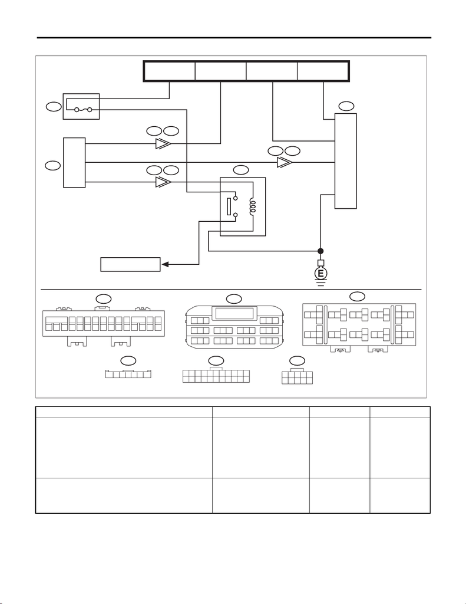

KPS(diag)-83

Diagnostic Procedure with Diagnostic Trouble Code (DTC)

KEYLESS ACCESS WITH PUSH BUTTON START SYSTEM (DIAGNOSTICS)

• Engine type: EJ

Step Check Yes No

1 CHECK FUSE.

Check the fuse.

Is the fuse OK? Go to step 2. Replace the fuse.

When the replaced

fuse is blown

immediately, check

the power supply

circuit for short-cir-

cuited.

2 CHECK CURRENT DATA.

Check the current data display of keyless

access CM using the Subaru Select Monitor.

•IGN SW

Is the display normal according

to the ignition switch operation?

Go to step 3. Go to step 5.

101

5

14

13

18

432

17

7

16

698

15

11 12

B550

B23

10

12345

6789

2

10

C5

3

B28 B23

B28 B23

B576 B575

39

36

37

38

B225

10

24

B550

20A

6

5

1

7

B424

B424

12345

6

7

B575

3412

12 13 14 15 16 17 18 19 20 21 22

589

10 11

67

C17

C6

C: B574

B225

10 11

12

13

14 15

16

18

19 21 22

20

17

24

5

3

17

9

8

6

32 33

34

35

25

27

29

30

31

36 37

38

40

41 43 44

42

39

C: B574

123

789

22 23 24 25 26 27

10 11 12 13 14 15

28 29 30

16 17 18

19 20 21

456

SL-02787

MB-31

SBF-6

(B)

REF. TO POWER SUPPLY

CIRCUIT

FB-38

F/B FUSE NO. 12

(IG)

FB-18

F/B FUSE NO. 7

(B)

FB-43

F/B FUSE NO. 32

(IG)

STEERING

LOCK CM

KEYLESS

ACCESS CM

FUSE HOLDER

IG RELAY 1

(PUSH BUTTON START)

RELAY BLOCK

[figure not shown]

KPS(diag)-84

Diagnostic Procedure with Diagnostic Trouble Code (DTC)

KEYLESS ACCESS WITH PUSH BUTTON START SYSTEM (DIAGNOSTICS)

3 CHECK HARNESS.

1) Disconnect the steering lock CM connector.

2) Using a tester, measure the resistance

between the steering lock CM connector and

chassis ground.

Connector & terminal

(B424) No. 1 — Chassis ground:

Is the resistance less than 1 Ω? Go to step 4. Repair or replace

the open circuit of

harness.

4 CHECK HARNESS.

1) Connect the steering lock CM connector.

2) Using the tester, measure the voltage

between terminals.

Connector & terminal

(B424) No. 6 (+) — (B424) No. 1 (–):

Is the voltage 11 — 14 V with IG

ON?

Is the voltage less than 1 V with

IG OFF?

Replace the steer-

ing lock CM. <Ref.

to SL-104,

REMOVAL, Steer-

ing Lock CM.>

Check the DC

power supply cir-

cuit.

5 CHECK HARNESS.

Using a tester, measure the voltage between

the keyless access CM connector and chassis

ground.

Connector & terminal

(B574) No. 5 (+) — Chassis ground (–):

Is the voltage 11 — 14 V with IG

ON?

Is the voltage less than 1 V with

IG OFF?

Replace the key-

less access CM.

<Ref. to SL-100,

REMOVAL, Key-

less Access CM.>

Check the DC

power supply cir-

cuit.

Step Check Yes No

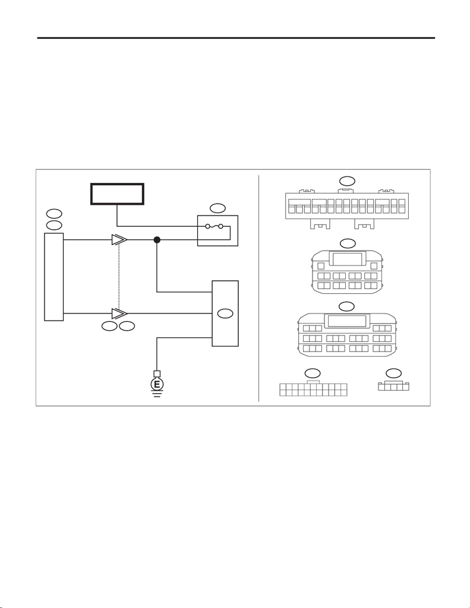

KPS(diag)-85

Diagnostic Procedure with Diagnostic Trouble Code (DTC)

KEYLESS ACCESS WITH PUSH BUTTON START SYSTEM (DIAGNOSTICS)

AA:DTC B2789 ID CODE BOX NO RESPONSE

DTC DETECTING CONDITION:

• When communication between keyless access CM and ID code box is interrupted for a set amount of time.

• Open or short circuit in the wiring harness between keyless access CM and ID code box

TROUBLE SYMPTOM:

Engine will not start.

CAUTION:

For replacement procedure of keyless access CM and ID code box, refer to the “REGISTRATION

MANUAL FOR IMMOBILIZER”.

WIRING DIAGRAM:

Push button start system <Ref. to WI-329, WIRING DIAGRAM, Push Button Start System.>

• Engine type: FA

C: B574

123

789

22 23 24 25 26 27

10 11 12 13 14 15

28 29 30

16 17 18

19 20 21

456

B422

12345

1

B422

91

2

4

13

12

17

3

16

6

15

587

14

10 11

B550

2

3

B576 B575

B575

3412

12 13 14 15 16 17 18 19 20 21 22

589

10 11

67

5

2C17

A2

B550

10

25

B574C:

B572A:

63

1

45 87

2

9

10

A: B572

SL-02788

MB-35

SBF-8

(B)

KEYLESS

ACCESS CM

FUSE HOLDER

7.5A

ID CODE BOX

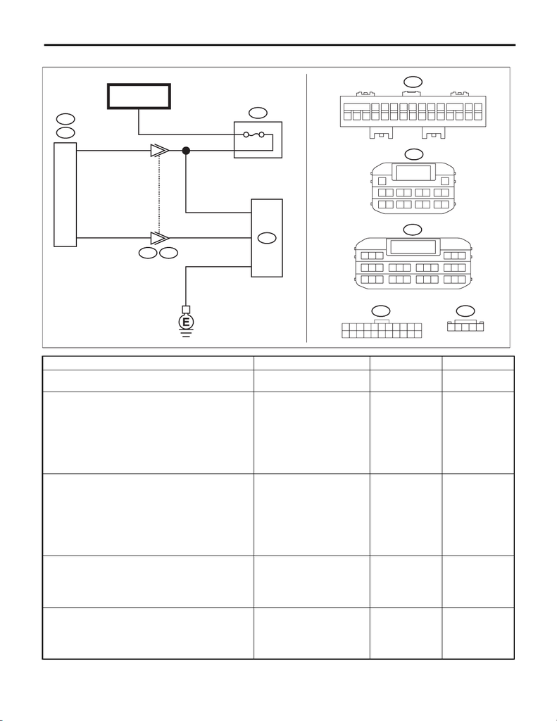

KPS(diag)-86

Diagnostic Procedure with Diagnostic Trouble Code (DTC)

KEYLESS ACCESS WITH PUSH BUTTON START SYSTEM (DIAGNOSTICS)

• Engine type: EJ

Step Check Yes No

1 CHECK DTC.

Use the Subaru Select Monitor and read DTCs.

Is B2789 displayed? Go to step 2. Check the connec-

tor.

2 CHECK HARNESS.

1) Disconnect the keyless access CM connec-

tor.

2) Disconnect the ID code box connector.

3) Using the tester, measure the resistance

between terminals.

Connector & terminal

(B574) No. 17 — (B422) No. 2:

Is the resistance less than 1 Ω? Go to step 3. Repair or replace

the open circuit of

harness.

3 CHECK HARNESS.

Using a tester, measure the resistance between

the keyless access CM connector and chassis

ground, and between ID code box connector

and chassis ground.

Connector & terminal

(B574) No. 17 — Chassis ground:

(B422) No. 2 — Chassis ground:

Is the resistance 10 kΩ or

more?

Go to step 4. Repair or replace

the short circuit of

the harness.

4 CHECK HARNESS.

Using a tester, measure the resistance between

ID code box connector and chassis ground.

Connector & terminal

(B422) No. 5 — Chassis ground:

Is the resistance less than 1 Ω? Go to step 5. Repair or replace

the open circuit of

harness.

5 CHECK HARNESS.

Using a tester, measure the voltage between ID

code box connector and chassis ground.

Connector & terminal

(B422) No. 1 (+) — Chassis ground (–):

Is the voltage 11 — 14 V? Go to step 6. Repair or replace

the open circuit of

harness.

C: B574

123

789

22 23 24 25 26 27

10 11 12 13 14 15

28 29 30

16 17 18

19 20 21

456

B574C:

101

5

14

13

18

432

17

7

16

698

15

11 12

B550

B422

12345

1

B422

2

3

B576 B575

B575

3412

12 13 14 15 16 17 18 19 20 21 22

589

10 11

67

5

2C17

A2

B550

11

26

B572A:

63

1

45 87

2

9

10

A: B572

SL-02789

MB-35

SBF-8

(B)

KEYLESS

ACCESS CM

FUSE HOLDER

7.5A

ID CODE BOX

[figure not shown]

KPS(diag)-87

Diagnostic Procedure with Diagnostic Trouble Code (DTC)

KEYLESS ACCESS WITH PUSH BUTTON START SYSTEM (DIAGNOSTICS)

6 CHECK ID CODE BOX.

1) Replace the ID code box. <Ref. to SL-103,

ID Code Box.>

2) Using the Subaru Select Monitor, clear the

memory.

3) Use the Subaru Select Monitor and read

DTCs.

Is B2789 displayed? Replace the key-

less access CM.

<Ref. to SL-100,

Keyless Access

CM.>

ID code box has an

error.

Step Check Yes No

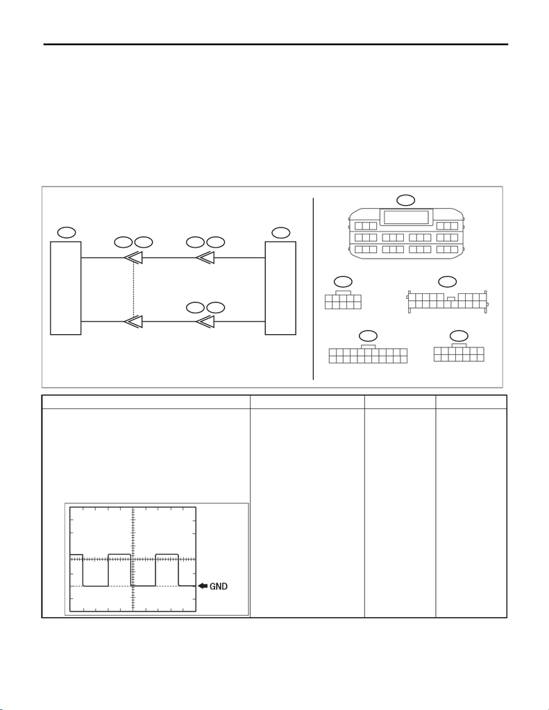

KPS(diag)-88

Diagnostic Procedure with Diagnostic Trouble Code (DTC)

KEYLESS ACCESS WITH PUSH BUTTON START SYSTEM (DIAGNOSTICS)

AB:DTC B278A ABNORMAL IMMOBILIZER POWER SUPPLY

DTC DETECTING CONDITION:

When the power supply circuit of the push button ignition switch is shorted to ground.

TROUBLE SYMPTOM:

• Engine will not start.

• The keyless access system function does not operate.

CAUTION:

For replacement procedure of keyless access CM, refer to the “REGISTRATION MANUAL FOR IMMO-

BILIZER”.

WIRING DIAGRAM:

Immobilizer system <Ref. to WI-259, WIRING DIAGRAM, Immobilizer System.>

Step Check Yes No

1 CHECK KEYLESS ACCESS CM.

1) Turn the ignition switch to OFF.

2) Take the access key out of the passenger

room.

3) Push the push button ignition switch. Within

30 seconds, use oscilloscope to measure the

waveform between connectors.

Connector & terminal

(i150) No. 14 — (i150) No. 8:

Is the waveform shown in the

left column displayed?

Replace the push

button ignition

switch. <Ref. to

SL-106, Push But-

ton Ignition

Switch.>

Go to step 2.

12345

6789

B23

12345 6789

i231

i150

1234567

89

10 11 12 13 14

23

456789

10 11

12 13 14 15 16 17 18 19 20 21 22

B575

B28B23

14

9

B553i231

15

18

C: B574

C24

8

C1

14

i150

C: B574

123

789

22 23 24 25 26 27

10 11 12 13 14 15

28 29 30

16 17 18

19 20 21

456

SL-02790

PUSH BUTTON

IGNITION SWITCH

KEYLESS

ACCESS CM

SL-00634

[figure not shown]

KPS(diag)-89

Diagnostic Procedure with Diagnostic Trouble Code (DTC)

KEYLESS ACCESS WITH PUSH BUTTON START SYSTEM (DIAGNOSTICS)

2 CHECK HARNESS.

1) Disconnect the keyless access CM connec-

tor.

2) Disconnect the push button ignition switch

connector.

3) Using the tester, measure the resistance

between terminals.

Connector & terminal

(i150) No. 14 — (B574) No. 1:

(i150) No. 8 — (B574) No. 24:

Is the resistance less than 1 Ω? Go to step 3. Repair or replace

the open circuit of

harness.

3 CHECK HARNESS.

Using a tester, measure the resistance between

the keyless access CM connector and chassis

ground.

Connector & terminal

(B574) No. 1 — Chassis ground:

Is the resistance 10 kΩ or

more?

Go to step 4. Repair or replace

the short circuit of

the harness.

4 CHECK HARNESS.

Using a tester, measure the resistance between

the keyless access CM connector and chassis

ground.

Connector & terminal

(B574) No. 24 — Chassis ground:

Is the resistance 1 Ω or less? Replace the key-

less access CM.

<Ref. to SL-100,

Keyless Access

CM.>

Repair or replace

the harness.

Step Check Yes No

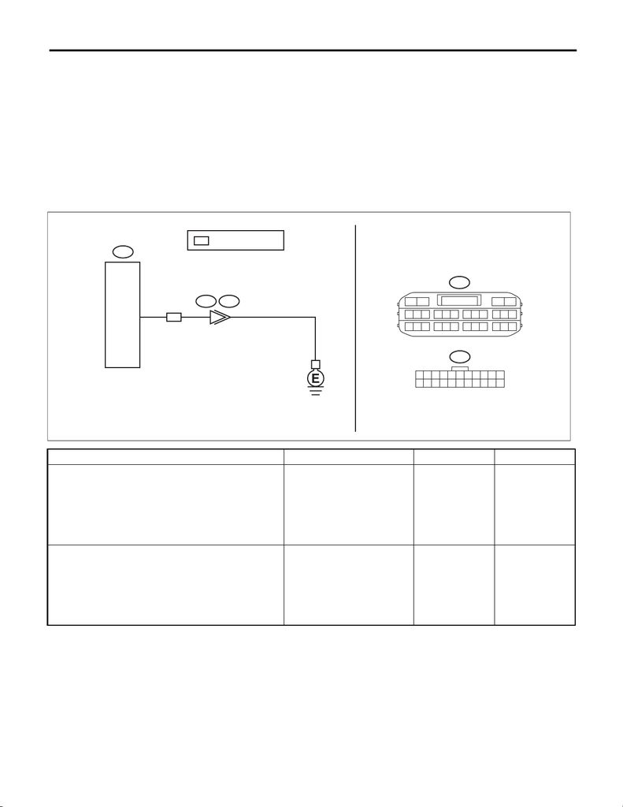

KPS(diag)-90

Diagnostic Procedure with Diagnostic Trouble Code (DTC)

KEYLESS ACCESS WITH PUSH BUTTON START SYSTEM (DIAGNOSTICS)

AC:DTC B278D ID CODE BOX RECOGNITION JUDGMENT ABNORMAL

DTC DETECTING CONDITION:

• When ID code box setting is set to OFF, ID code box ON input is detected.

• When ID code box setting is set to OFF, ID code box LIN signal is received.

TROUBLE SYMPTOM:

Engine will not start.

CAUTION:

For replacement procedure of keyless access CM, refer to the “REGISTRATION MANUAL FOR IMMO-

BILIZER”.

WIRING DIAGRAM:

Push button start system <Ref. to WI-329, WIRING DIAGRAM, Push Button Start System.>

Step Check Yes No

1 CHECK DTC.

1) Turn the ignition switch to OFF.

2) Using the Subaru Select Monitor, clear the

keyless access system memory.

3) Turn the ignition switch to OFF → ON.

4) Use the Subaru Select Monitor and read

DTCs.

Is B278D displayed? Go to step 2. System is normal.

It is possible that

temporary poor

contact occurs.

2 CHECK HARNESS.

1) Disconnect the keyless access CM connec-

tor.

2) Measure the resistance between keyless

access CM connector and chassis ground.

Connector & terminal

(B573) No. 15 — Chassis ground:

Is the resistance 10 kΩ or

more?

Replace the key-

less access CM.

<Ref. to SL-100,

Keyless Access

CM.>

Repair or replace

the short circuit of

the harness.

123

456789

10 11

B575

12

89

10 11 12 13 14 15 16

567

34

B: B573

ID

ID

B575B576

12

B: B573

B15

SL-02791

KEYLESS

ACCESS CM

: WITH ID CODE BOX

[figure not shown]

KPS(diag)-91

Diagnostic Procedure with Diagnostic Trouble Code (DTC)

KEYLESS ACCESS WITH PUSH BUTTON START SYSTEM (DIAGNOSTICS)

AD:DTC B2790 ID CODE BOX ABNORMAL (EEPROM ABNORMAL)

DTC DETECTING CONDITION:

An error has occurred inside the ID code box.

TROUBLE SYMPTOM:

Engine will not start.

CAUTION:

For replacement procedure of ID code box, refer to the “REGISTRATION MANUAL FOR IMMOBILIZ-

ER”.

Step Check Yes No

1 CHECK DTC.

1) Turn the ignition switch to OFF.

2) Using the Subaru Select Monitor, clear the

keyless access system memory.

3) Turn the ignition switch to OFF → ON.

4) Register the ID code box.

5) Use the Subaru Select Monitor and read

DTCs.

Is B2790 displayed? Replace the ID

code box. <Ref. to

SL-103, ID Code

Box.>

System is normal.

It is possible that

temporary poor

contact occurs.

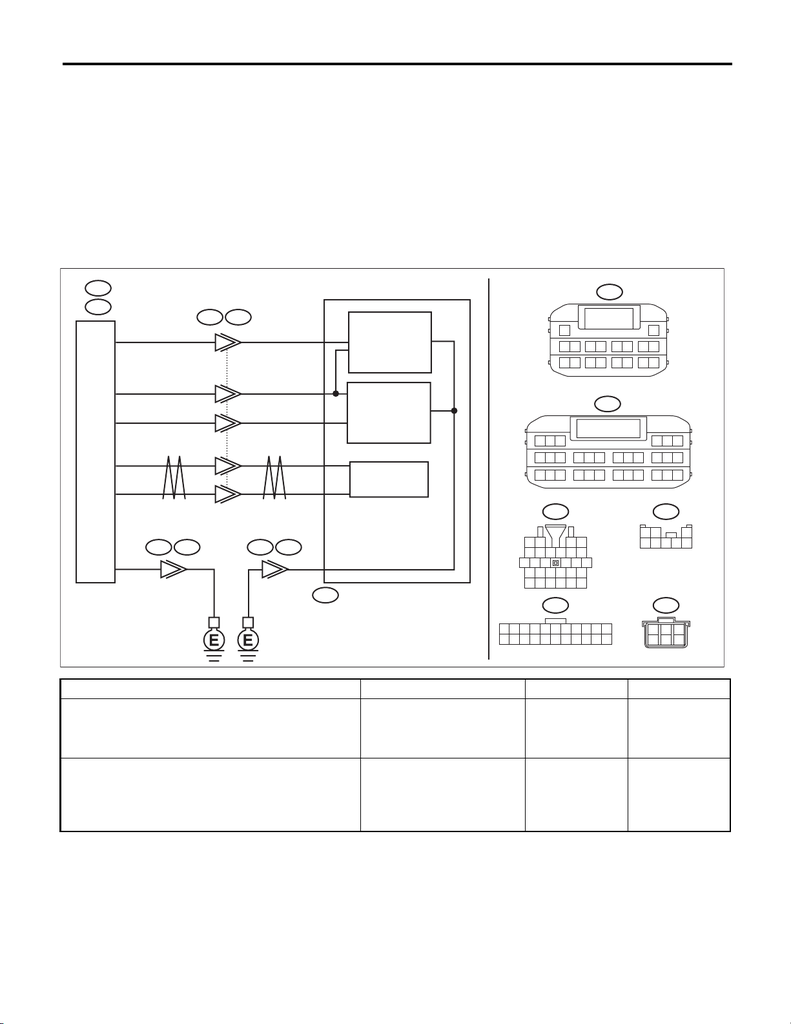

KPS(diag)-92

Diagnostic Procedure with Diagnostic Trouble Code (DTC)

KEYLESS ACCESS WITH PUSH BUTTON START SYSTEM (DIAGNOSTICS)

AE:DTC B27A1 DRIVER SIDE EXTERNAL ANTENNA OUTPUT STAGE OPEN

DTC DETECTING CONDITION:

When open circuit occurs in the harness between keyless access CM and driver’s side front door outer han-

dle.

TROUBLE SYMPTOM:

Keyless access system does not function.

CAUTION:

For replacement procedure of keyless access CM, refer to the “REGISTRATION MANUAL FOR IMMO-

BILIZER”.

WIRING DIAGRAM:

Keyless access system <Ref. to WI-275, WIRING DIAGRAM, Keyless Access System.>

Step Check Yes No

1 CHECK LAN SYSTEM.

Inspect LAN system. <Ref. to LAN(diag)-2,

PROCEDURE, Basic Diagnostic Procedure.>

Is LAN system normal? Go to step 2. Perform the

inspection accord-

ing to the diagnosis

for LAN system.

2 CHECK CONNECTOR.

1) Disconnect the keyless access CM connec-

tor.

2) Disconnect the front door outer handle con-

nector.

Is the connector OK? Go to step 3. Repair or replace

the connector.

123

456789

10 11

12 13 14 15 16 17 18 19 20 21 22

B575

D84

19

18

20 21 22

1

3

24

5

7

6

98

10

17

25

24

16

D11

321

87654

20

B576 B575

3

i101 D84

4

1

2

5

6

A11

2

3

6

1

5

4

D11B101

C13

C12

C19

C20

C22

D66

B574C:

B572A:

63

1

45 87

2

9

10

A: B572

D66

1

4

3

6

2

5

C: B574

123

789

22 23 24 25 26 27

10 11 12 13 14 15

28 29 30

16 17 18

19 20 21

456

SL-02792

ANTENNA

TOUCH SENSOR

(UNLOCK)

TOUCH SENSOR

(LOCK)

KEYLESS

ACCESS CM

OUTER HANDLE LH

[figure not shown]

KPS(diag)-93

Diagnostic Procedure with Diagnostic Trouble Code (DTC)

KEYLESS ACCESS WITH PUSH BUTTON START SYSTEM (DIAGNOSTICS)

3 CHECK HARNESS.

Using a tester, measure the resistance between

the keyless access CM connector and front

door outer handle connector, and between front

door outer handle connector and chassis

ground.

Connector & terminal

(B574) No. 12 — (D66) No. 6:

(B574) No. 13 — (D66) No. 3:

(D66) No. 2 — Chassis ground:

(B572) No. 11 — Chassis ground:

Is the resistance less than 1 Ω? Go to step 4. Repair or replace

the open circuit of

harness.

4 CHECK HARNESS.

Using a tester, measure the resistance between

the keyless access CM connector and chassis

ground, and between front door outer handle

connector and chassis ground.

Connector & terminal

(B574) No. 12 — Chassis ground:

(B574) No. 13 — Chassis ground:

(D66) No. 6 — Chassis ground:

(D66) No. 3 — Chassis ground:

Is the resistance 10 kΩ or

more?

Go to step 5. Repair or replace

the short circuit of

the harness.

5 CHECK KEYLESS ACCESS CM.

1) Connect the keyless access CM connector.

2) Use an oscilloscope, measure the wave-

form between terminals with ignition switch

OFF, all doors closed and access key not in pas-

senger room.

Connector & terminal

(B574) No. 12 — (B572) No. 11:

(B574) No. 13 — (B572) No. 11:

Does pulse output change from

pulse output OFF → pulse out-

put ON by the lock operation

using access key?

Go to step 6. Replace the key-

less access CM.

<Ref. to SL-100,

Keyless Access

CM.>

6 CHECK FRONT DOOR OUTER HANDLE.

1) Replace the driver’s front door outer handle

with the passenger’s front door outer handle.

2) Read DTC using the Subaru Select Monitor.

Is B27A1 displayed? Replace the key-

less access CM.

<Ref. to SL-100,

Keyless Access

CM.>

Replace the

driver’s front door

outer handle. <Ref.

to SL-33, Front

Outer Handle.>

Step Check Yes No

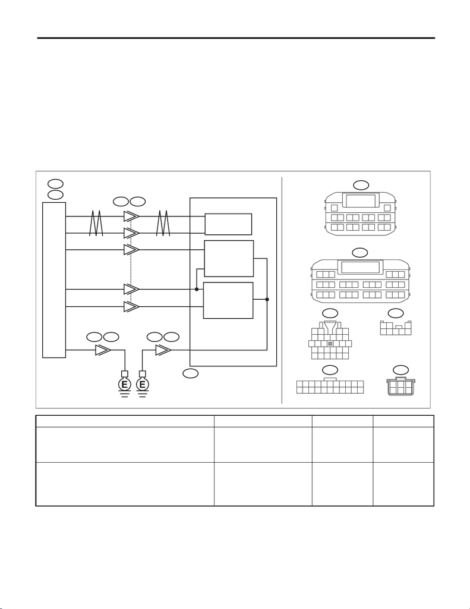

KPS(diag)-94

Diagnostic Procedure with Diagnostic Trouble Code (DTC)

KEYLESS ACCESS WITH PUSH BUTTON START SYSTEM (DIAGNOSTICS)

AF:DTC B27A2 PASSENGER SIDE EXTERNAL ANTENNA OUTPUT STAGE

OPEN

DTC DETECTING CONDITION:

When open circuit occurs in the harness between keyless access CM and passenger’s side front door outer

handle.

TROUBLE SYMPTOM:

Keyless access system does not function.

CAUTION:

For replacement procedure of keyless access CM, refer to the “REGISTRATION MANUAL FOR IMMO-

BILIZER”.

WIRING DIAGRAM:

Keyless access system <Ref. to WI-275, WIRING DIAGRAM, Keyless Access System.>

Step Check Yes No

1 CHECK LAN SYSTEM.

Inspect LAN system. <Ref. to LAN(diag)-2,

PROCEDURE, Basic Diagnostic Procedure.>

Is LAN system normal? Go to step 2. Perform the

inspection accord-

ing to the diagnosis

for LAN system.

2 CHECK CONNECTOR.

1) Disconnect the keyless access CM connec-

tor.

2) Disconnect the front door outer handle con-

nector.

Is the connector OK? Go to step 3. Repair or replace

the connector.

123

456789

10 11

B575

D83

19

18

20 21 22

1

3

24

5

7

6

98

10

17

25

24

16

D1

321

87654

20

B576 B575

A11

3

6

1

5

2

4

3

6

C10

C11

2

4

5

1

C21

C23

C8

D56

63

1

45 87

2

9

10

A: B572

D56

1

4

3

6

2

5

C: B574

123

789

22 23 24 25 26 27

10 11 12 13 14 15

28 29 30

16 17 18

19 20 21

456

SL-02793

TOUCH SENSOR

(UNLOCK)

TOUCH SENSOR

(LOCK)

KEYLESS

ACCESS CM

OUTER HANDLE RH

ANTENNA

[figure not shown]

KPS(diag)-95

Diagnostic Procedure with Diagnostic Trouble Code (DTC)

KEYLESS ACCESS WITH PUSH BUTTON START SYSTEM (DIAGNOSTICS)

3 CHECK HARNESS.

Using a tester, measure the resistance between

the keyless access CM connector and front

door outer handle connector, and between front

door outer handle connector and chassis

ground.

Connector & terminal

(B574) No. 11 — (D56) No. 6:

(B574) No. 10 — (D56) No. 3:

(D56) No. 2 — Chassis ground:

(B572) No. 11 — Chassis ground:

Is the resistance less than 1 Ω? Go to step 4. Repair or replace

the open circuit of

harness.

4 CHECK HARNESS.

Using a tester, measure the resistance between

the keyless access CM connector and chassis

ground, and between front door outer handle

connector and chassis ground.

Connector & terminal

(B574) No. 11 — Chassis ground:

(B574) No. 10 — Chassis ground:

(D56) No. 6 — Chassis ground:

(D56) No. 3 — Chassis ground:

Is the resistance 10 kΩ or

more?

Go to step 5. Repair or replace

the short circuit of

the harness.

5 CHECK KEYLESS ACCESS CM.

1) Connect the keyless access CM connector.

2) Use an oscilloscope, measure the wave-

form between terminals with ignition switch

OFF, all doors closed and access key not in pas-

senger room.

Does pulse output change from

pulse output OFF → pulse out-

put ON by the lock operation

using access key?

Go to step 6. Replace the key-

less access CM.

<Ref. to SL-100,

Keyless Access

CM.>

6 CHECK FRONT DOOR OUTER HANDLE.

1) Replace the passenger’s front door outer

handle with the driver’s front door outer handle.

2) Read DTC using the Subaru Select Monitor.

Is B27A2 displayed? Replace the key-

less access CM.

<Ref. to SL-100,

Keyless Access

CM.>

Replace the pas-

senger’s front door

outer handle. <Ref.

to SL-33, Front

Outer Handle.>

Step Check Yes No

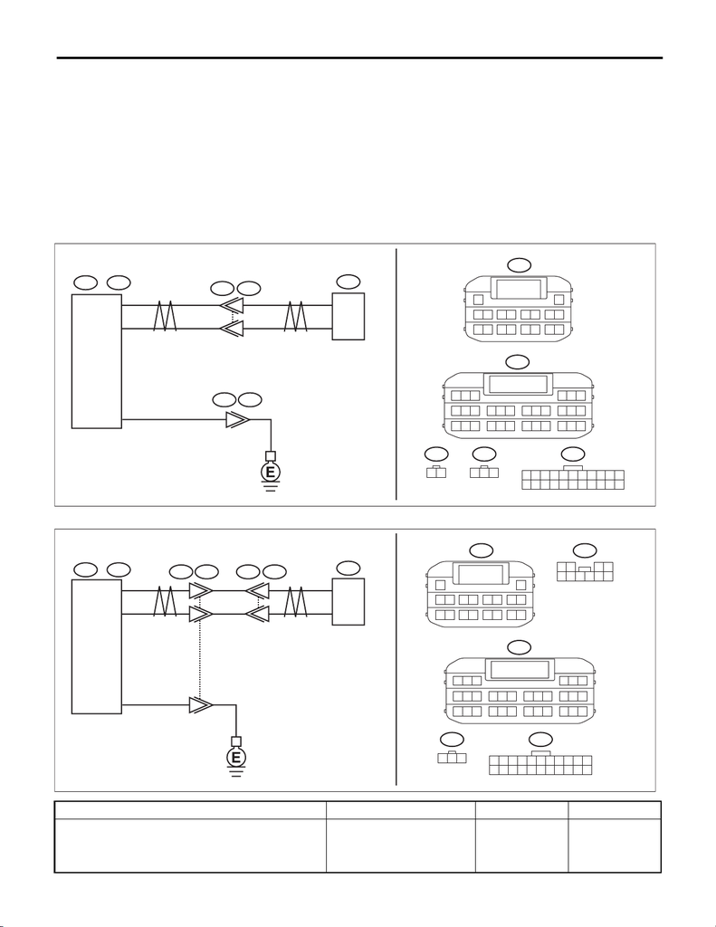

KPS(diag)-96

Diagnostic Procedure with Diagnostic Trouble Code (DTC)

KEYLESS ACCESS WITH PUSH BUTTON START SYSTEM (DIAGNOSTICS)

AG:DTC B27A5 FRONT INTERNAL ANTENNA OUTPUT STAGE OPEN

DTC DETECTING CONDITION:

When open circuit occurs in the harness between keyless access CM and front interior antenna.

TROUBLE SYMPTOM:

Keyless access system does not function. (when the access key is in the front area of the passenger room)

CAUTION:

For replacement procedure of keyless access CM, refer to the “REGISTRATION MANUAL FOR IMMO-

BILIZER”.

WIRING DIAGRAM:

Keyless access system <Ref. to WI-275, WIRING DIAGRAM, Keyless Access System.>

• Engine type: FA

• Engine type: EJ

Step Check Yes No

1 CHECK LAN SYSTEM.

Inspect LAN system. <Ref. to LAN(diag)-2,

PROCEDURE, Basic Diagnostic Procedure.>

Is LAN system normal? Go to step 2. Perform the

inspection accord-

ing to the diagnosis

for LAN system.

21

B579

2

1

123

456789

10 11

12 13 14 15 16 17 18 19 20 21 22

B575

231

AD12

20

B576 B575

A11

1

3C2

C3

AD12

SL-02848

63

1

45 87

2

9

10

A: B572

C: B574

123

789

22 23 24 25 26 27

10 11 12 13 14 15

28 29 30

16 17 18

19 20 21

456

KEYLESS ACCESS

INTERIOR ANTENNA

(FRONT)

KEYLESS

ACCESS CM

63

1

45 87

2

9

10

A: B572 B4

8765

21

10

9

43

8

22

123

456789

10 11

12 13 14 15 16 17 18 19 20 21 22

B575

231

AD12

9

3

20

B576 B575

A11

1

3C2

C3

AD12

SL-02849

C: B574A: B572

C: B574

123

789

22 23 24 25 26 27

10 11 12 13 14 15

28 29 30

16 17 18

19 20 21

456

KEYLESS ACCESS

INTERIOR ANTENNA

(FRONT)

KEYLESS

ACCESS CM

[figure not shown]

KPS(diag)-97

Diagnostic Procedure with Diagnostic Trouble Code (DTC)

KEYLESS ACCESS WITH PUSH BUTTON START SYSTEM (DIAGNOSTICS)

2 CHECK CONNECTOR.

1) Disconnect the keyless access CM connec-

tor.

2) Disconnect the front interior antenna con-

nector.

Is the connector OK? Go to step 3. Repair or replace

the connector.

3 CHECK HARNESS.

Using a tester, measure the resistance between

the keyless access CM connector and front

interior antenna connector, and between front

interior antenna connector and chassis ground.

Connector & terminal

(B574) No. 3 — (AD12) No. 1:

(B574) No. 2 — (AD12) No. 3:

(B572) No. 11 — Chassis ground:

Is the resistance less than 1 Ω? Go to step 4. Repair or replace

the open circuit of

harness.

4 CHECK HARNESS.

Using a tester, measure the resistance between

the keyless access CM connector and chassis

ground, and between front interior antenna con-

nector and chassis ground.

Connector & terminal

(B574) No. 3 — Chassis ground:

(AD12) No. 1 — Chassis ground:

(B574) No. 2 — Chassis ground:

(AD12) No. 3 — Chassis ground:

Is the resistance 10 kΩ or

more?

Go to step 5. Repair or replace

the short circuit of

the harness.

5 CHECK KEYLESS ACCESS CM.

1) Connect the keyless access CM connector.

2) Use an oscilloscope, measure the wave-

form between terminals with ignition switch

OFF, all doors closed and access key not in pas-

senger room.

Connector & terminal

(B574) No. 3 — (B572) No. 11:

(B574) No. 2 — (B572) No. 11:

Does pulse output change from

pulse output OFF → pulse out-

put ON by operating the touch

sensor (lock)?

Go to step 6. Replace the key-

less access CM.

<Ref. to SL-100,

Keyless Access

CM.>

6 CHECK FRONT INTERIOR ANTENNA.

1) Replace the front interior antenna. <Ref. to

SL-92, Keyless Access Indoor Antenna.>

2) Read DTC using the Subaru Select Monitor.

Is B27A5 displayed? Replace the key-

less access CM.

<Ref. to SL-100,

Keyless Access

CM.>

Malfunction

occurred in the

front interior

antenna.

Step Check Yes No

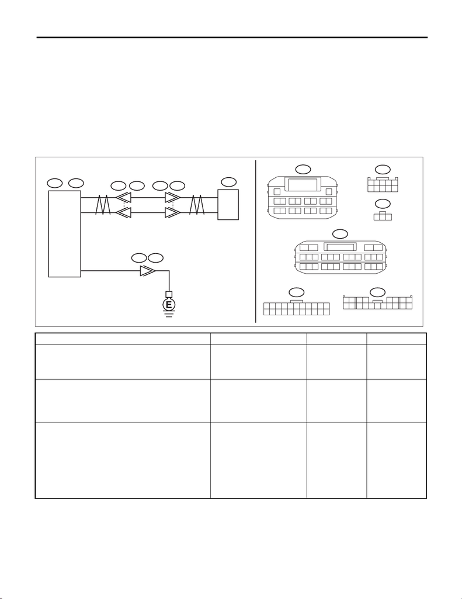

KPS(diag)-98

Diagnostic Procedure with Diagnostic Trouble Code (DTC)

KEYLESS ACCESS WITH PUSH BUTTON START SYSTEM (DIAGNOSTICS)

AH:DTC B27A6 REAR INTERNAL ANTENNA OUTPUT STAGE OPEN

DTC DETECTING CONDITION:

When open circuit occurs in the harness between keyless access CM and center interior antenna.

TROUBLE SYMPTOM:

Keyless access system does not function. (when the access key is in the rear area of the passenger room

(near the seat))

CAUTION:

For replacement procedure of keyless access CM, refer to the “REGISTRATION MANUAL FOR IMMO-

BILIZER”.

WIRING DIAGRAM:

Keyless access system <Ref. to WI-275, WIRING DIAGRAM, Keyless Access System.>

Step Check Yes No

1 CHECK LAN SYSTEM.

Inspect LAN system. <Ref. to LAN(diag)-2,

PROCEDURE, Basic Diagnostic Procedure.>

Is LAN system normal? Go to step 2. Perform the

inspection accord-

ing to the diagnosis

for LAN system.

2 CHECK CONNECTOR.

1) Disconnect the keyless access CM connec-

tor.

2) Disconnect the center interior antenna con-

nector.

Is the connector OK? Go to step 3. Repair or replace

the connector.

3 CHECK HARNESS.

Using a tester, measure the resistance between

the keyless access CM connector and center

interior antenna connector, and between center

interior antenna connector and chassis ground.

Connector & terminal

(B573) No. 10 — (R298) No. 3:

(B573) No. 11 — (R298) No. 1:

(B572) No. 11 — Chassis ground:

Is the resistance less than 1 Ω? Go to step 4. Repair or replace

the open circuit of

harness.

123

456789

10 11

12 13 14 15 16 17 18 19 20 21 22

B575 R82

1

9

234 5678

B92

91078

5

6

3421

7

8

R81 R82

20

B576 B575

A11

123

R298

63

1

45 87

2

9

10

A: B572

6

1

3

1B11

B10

R298

B: B573

12

89

10 11 12 13 14 15 16

567

34

SL-02795

B: B573A: B572

KEYLESS

ACCESS CM

KEYLESS ACCESS

INTERIOR ANTENNA

(CENTER)

[figure not shown]

KPS(diag)-99

Diagnostic Procedure with Diagnostic Trouble Code (DTC)

KEYLESS ACCESS WITH PUSH BUTTON START SYSTEM (DIAGNOSTICS)

4 CHECK HARNESS.

Using a tester, measure the resistance between

the keyless access CM connector and chassis

ground, and between center interior antenna

connector and chassis ground.

Connector & terminal

(B573) No. 10 — Chassis ground:

(B573) No. 11 — Chassis ground:

(R298) No. 1 — Chassis ground:

(R298) No. 3 — Chassis ground:

Is the resistance 10 kΩ or

more?

Go to step 5. Repair or replace

the short circuit of

the harness.

5 CHECK KEYLESS ACCESS CM.

1) Connect the keyless access CM connector.

2) Use an oscilloscope, measure the wave-

form between terminals with ignition switch

OFF, all doors closed and access key not in pas-

senger room.

Connector & terminal

(B573) No. 10 — (B572) No. 11:

(B573) No. 11 — (B572) No. 11:

Does pulse output change from

pulse output OFF → pulse out-

put ON by operating the touch

sensor (lock)?

Go to step 6. Replace the key-

less access CM.

<Ref. to SL-100,

Keyless Access

CM.>

6 CHECK CENTER INTERIOR ANTENNA.

1) Replace the center interior antenna. <Ref.

to SL-92, Keyless Access Indoor Antenna.>

2) Read DTC using the Subaru Select Monitor.

Is B27A6 displayed? Replace the key-

less access CM.

<Ref. to SL-100,

Keyless Access

CM.>

Malfunction

occurred in the

center interior

antenna.

Step Check Yes No

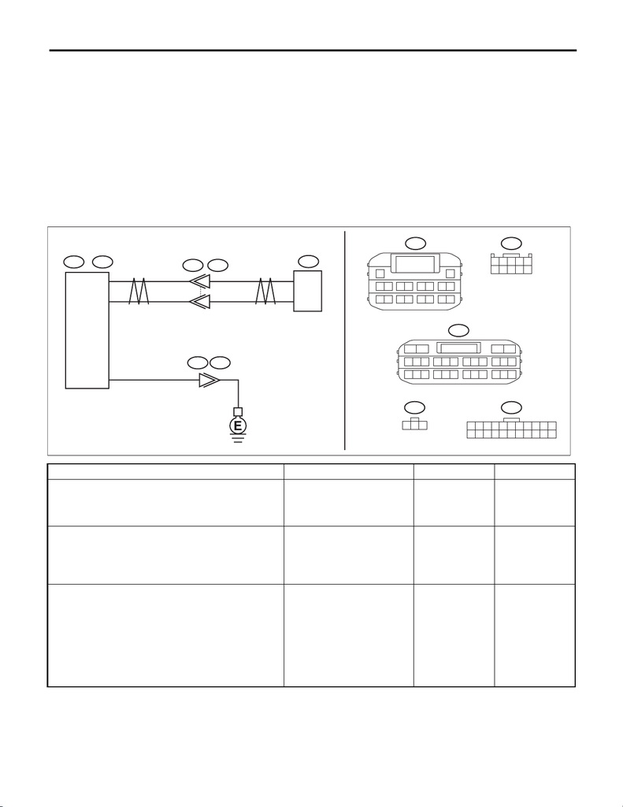

KPS(diag)-100

Diagnostic Procedure with Diagnostic Trouble Code (DTC)

KEYLESS ACCESS WITH PUSH BUTTON START SYSTEM (DIAGNOSTICS)

AI: DTC B27A7 TRUNK/REAR GATE INTERNAL ANTENNA OUTPUT STAGE

OPEN

DTC DETECTING CONDITION:

When open circuit occurs in the harness between keyless access CM and rear interior antenna.

TROUBLE SYMPTOM:

Keyless access system does not function. (when the access key is in the rear area of the passenger room

(in the luggage room or trunk))

CAUTION:

For replacement procedure of keyless access CM, refer to the “REGISTRATION MANUAL FOR IMMO-

BILIZER”.

WIRING DIAGRAM:

Keyless access system <Ref. to WI-275, WIRING DIAGRAM, Keyless Access System.>

Step Check Yes No

1 CHECK LAN SYSTEM.

Inspect LAN system. <Ref. to LAN(diag)-2,

PROCEDURE, Basic Diagnostic Procedure.>

Is LAN system normal? Go to step 2. Perform the

inspection accord-

ing to the diagnosis

for LAN system.

2 CHECK CONNECTOR.

1) Disconnect the keyless access CM connec-

tor.

2) Disconnect the rear interior antenna con-

nector.

Is the connector OK? Go to step 3. Repair or replace

the connector.

3 CHECK HARNESS.

Using a tester, measure the resistance between

the keyless access CM connector and rear inte-

rior antenna connector, and between rear inte-

rior antenna connector and chassis ground.

Connector & terminal

(B573) No. 9 — (R297) No. 1:

(B573) No. 8 — (R297) No. 3:

(B572) No. 11 — Chassis ground:

Is the resistance less than 1 Ω? Go to step 4. Repair or replace

the open circuit of

harness.

123

456789

10 11

12 13 14 15 16 17 18 19 20 21 22

B575

B92

91078

5

6

3421

20

B576 B575

A11

123

R297

63

1

45 87

2

9

10

A: B572

7

2

R5B92

3

1B9

B8

R297

B: B573

12

89

10 11 12 13 14 15 16

567

34

SL-02796

B: B573A: B572

KEYLESS

ACCESS CM

KEYLESS ACCESS

INTERIOR ANTENNA

(REAR)

[figure not shown]

KPS(diag)-101

Diagnostic Procedure with Diagnostic Trouble Code (DTC)

KEYLESS ACCESS WITH PUSH BUTTON START SYSTEM (DIAGNOSTICS)

4 CHECK HARNESS.

Using a tester, measure the resistance between

the keyless access CM connector and chassis

ground, and between rear interior antenna con-

nector and chassis ground.

Connector & terminal

(B573) No. 9 — Chassis ground:

(B573) No. 8 — Chassis ground:

(R297) No. 1 — Chassis ground:

(R297) No. 3 — Chassis ground:

Is the resistance 10 kΩ or

more?

Go to step 5. Repair or replace

the short circuit of

the harness.

5 CHECK KEYLESS ACCESS CM.

1) Connect the keyless access CM connector.

2) Use an oscilloscope, measure the wave-

form between terminals with ignition switch

OFF, all doors closed and access key not in pas-

senger room.

Connector & terminal

(B573) No. 9 — (B572) No. 11:

(B573) No. 8 — (B572) No. 11:

Does pulse output change from

pulse output OFF → pulse out-

put ON by operating the touch

sensor (lock)?

Go to step 6. Replace the key-

less access CM.

<Ref. to SL-100,

Keyless Access

CM.>

6 CHECK REAR INTERIOR ANTENNA.

1) Replace the rear interior antenna. <Ref. to

SL-92, Keyless Access Indoor Antenna.>

2) Read DTC using the Subaru Select Monitor.

Is B27A7 displayed? Replace the key-

less access CM.

<Ref. to SL-100,

Keyless Access

CM.>

Malfunction

occurred in the

rear interior

antenna.

Step Check Yes No

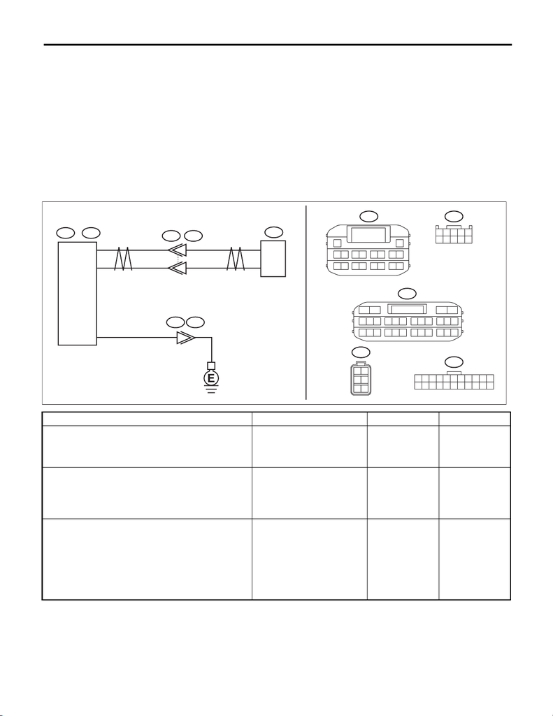

KPS(diag)-102

Diagnostic Procedure with Diagnostic Trouble Code (DTC)

KEYLESS ACCESS WITH PUSH BUTTON START SYSTEM (DIAGNOSTICS)

AJ:DTC B27A8 TRUNK/REAR GATE EXTERNAL ANTENNA OUTPUT STAGE

OPEN

DTC DETECTING CONDITION:

When open circuit occurs in the harness between keyless access CM and rear exterior antenna.

TROUBLE SYMPTOM:

Keyless access system does not function.

(Unable to unlock with the rear gate opener button, or unable to lock with the rear lock button.)

CAUTION:

For replacement procedure of keyless access CM, refer to the “REGISTRATION MANUAL FOR IMMO-

BILIZER”.

WIRING DIAGRAM:

Keyless access system <Ref. to WI-275, WIRING DIAGRAM, Keyless Access System.>

Step Check Yes No

1 CHECK LAN SYSTEM.

Inspect LAN system. <Ref. to LAN(diag)-2,

PROCEDURE, Basic Diagnostic Procedure.>

Is LAN system normal? Go to step 2. Perform the

inspection accord-

ing to the diagnosis

for LAN system.

2 CHECK CONNECTOR.

1) Disconnect the keyless access CM connec-

tor.

2) Disconnect the rear exterior antenna con-

nector.

Is the connector OK? Go to step 3. Repair or replace

the connector.

3 CHECK HARNESS.

Using a tester, measure the resistance between

the keyless access CM connector and rear

exterior antenna connector, and between rear

exterior antenna connector and chassis ground.

Connector & terminal

(B573) No. 2 — (R299) No. 1:

(B573) No. 1 — (R299) No. 2:

Is the resistance less than 1 Ω? Go to step 4. Repair or replace

the open circuit of

harness.

R299

56

34

12

123

456789

10 11

12 13 14 15 16 17 18 19 20 21 22

B575

B92

91078

5

6

3421

20

B576 B575

A11

63

1

45 87

2

9

10

A: B572

8

3

R5B92

2

1B2

B1

R299

B: B573

12

89

10 11 12 13 14 15 16

567

34

SL-02797

B: B573A: B572

KEYLESS

ACCESS CM

KEYLESS ACCESS

EXTERIOR ANTENNA

(REAR)

[figure not shown]

KPS(diag)-103

Diagnostic Procedure with Diagnostic Trouble Code (DTC)

KEYLESS ACCESS WITH PUSH BUTTON START SYSTEM (DIAGNOSTICS)

4 CHECK HARNESS.

Using a tester, measure the resistance between

the keyless access CM connector and chassis

ground, and between rear exterior antenna con-

nector and chassis ground.

Connector & terminal

(B573) No. 2 — Chassis ground:

(B573) No. 1 — Chassis ground:

(R299) No. 1 — Chassis ground:

(R299) No. 2 — Chassis ground:

Is the resistance 10 kΩ or

more?

Go to step 5. Repair or replace

the short circuit of

the harness.

5 CHECK REAR EXTERIOR ANTENNA.

1) Remove the rear exterior antenna.

2) Using a tester, measure the resistance

between rear exterior antenna connectors.

Connector & terminal

(R299) No. 1 — No. 2:

Is the resistance less than 1 Ω? Go to step 6. Replace the rear

exterior antenna.

<Ref. to SL-95,

Keyless Access

Outdoor

Antenna.>

6 CHECK KEYLESS ACCESS CM.

1) Replace the keyless access CM. <Ref. to

SL-100, Keyless Access CM.>

2) Read DTC using the Subaru Select Monitor.

Is B27A8 displayed? Replace the rear

exterior antenna.

<Ref. to SL-95,

Keyless Access

Outdoor

Antenna.>

Malfunction

occurred in the

keyless access

CM.

Step Check Yes No

[figure not shown]

KPS(diag)-104

Diagnostic Procedure with Diagnostic Trouble Code (DTC)

KEYLESS ACCESS WITH PUSH BUTTON START SYSTEM (DIAGNOSTICS)

AK:DTC B1571 REFERENCE CODE INCOMPATIBILITY

DTC DETECTING CONDITION:

Incompatibility of reference code between keyless access CM (model without ID code box) or ID code box

(model with ID code box) and ECM occurs.

TROUBLE SYMPTOM:

Engine will not start.

Step Check Yes No

1 CHECK ECM.

Perform ECM registration. Refer to the “REGIS-

TRATION MANUAL FOR IMMOBILIZER”.

Is ECM registration finished?

And does the engine start?

System is normal. Go to step 2.

2 REPLACE ECM.

1) Install the ECM from other normal operating

vehicle (with push button start) which use same

ECM to the vehicle to be diagnosed.

2) Perform ECM registration. Refer to the

“REGISTRATION MANUAL FOR IMMOBI-

LIZER”.

Is ECM registration finished?

And does the engine start?

Replace the ECM.

<Ref. to FU(w/o

STI)-132,

REMOVAL, Engine

Control Module

(ECM).> <Ref. to

FU(STI)-56,

REMOVAL, Engine

Control Module

(ECM).> Install the

ECM from other

vehicle to the origi-

nal vehicle.

Replace Keyless

access CM (model

without ID code

box), <Ref. to SL-

100, Keyless

Access CM.> or

replace ID code

box (model with ID

code box). <Ref. to

SL-103, NOTE, ID

Code Box.>

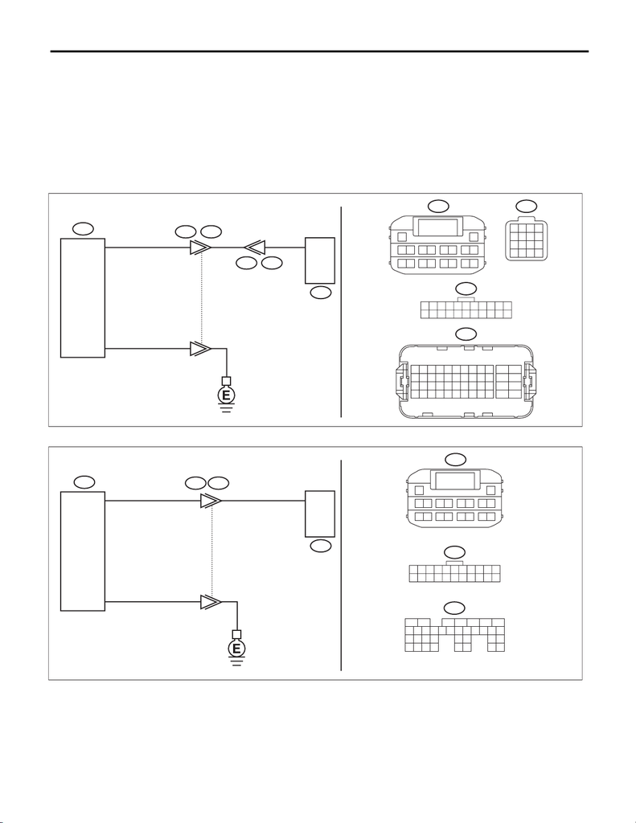

KPS(diag)-105

Diagnostic Procedure with Diagnostic Trouble Code (DTC)

KEYLESS ACCESS WITH PUSH BUTTON START SYSTEM (DIAGNOSTICS)

AL:DTC B1572 IMM CIRCUIT FAILURE (EXCEPT ANTENNA CIRCUIT)

1. EXCEPT FOR C0 MODEL

DTC DETECTING CONDITION:

Communication error between keyless access CM and ECM

TROUBLE SYMPTOM:

Engine will not start.

WIRING DIAGRAM:

Push button start system <Ref. to WI-329, WIRING DIAGRAM, Push Button Start System.>

• Engine type: FA

• Engine type: EJ

20

A11

63

1

45 87

2

9

10

A: B572

15 1613 14

11

12

9

10

7856

341

2

B22

7

9

10

8

5

23

11 12

6

19

21

22

20

17

24

35 36

47 48

18

31

33

34

32

29 30

43

45

46

44

41 42

3

4

12

15

16

13 14

27

28

25 26

39

40

37 38

B:

E158

B575

3412

12 13 14 15 16 17 18 19 20 21 22

589

10 11

67

14

B575B576

19

B43

A13

B:

E158

A: B572

SL-02798

ECM

KEYLESS

ACCESS CM

29

10 11 12 13 14 15

2524

16

30

98

17 18 19

20

28

21 22 23

3231

26 27

33 34 35

20

B576 B575

A11

63

1

45 87

2

9

10

A: B572

B575

3412

12 13 14 15 16 17 18 19 20 21 22

589

10 11

67

19

B25

A13

B:

B135

A: B572

SL-02799

ECM

KEYLESS

ACCESS CM

[figure not shown]

KPS(diag)-106

Diagnostic Procedure with Diagnostic Trouble Code (DTC)

KEYLESS ACCESS WITH PUSH BUTTON START SYSTEM (DIAGNOSTICS)

Step Check Yes No

1 CHECK CURRENT DATA.

1) Turn the ignition switch to ON.

2) Check the keyless access CM data using

the Subaru Select Monitor.

3) Display the next data. “Immobilizer” “Engine

start” “Unlock confirmation”

Data

Immobilizer = Unset:

Engine start = Engine start permission:

Unlock confirmation = Confirmed:

Is the data displayed as

described above?

Go to step 2. Perform diagnos-

tics with phenome-

non. <Ref. to

KPS(diag)-141,

ENGINE DOES

NOT START,

INSPECTION,

Diagnostics with

Phenomenon.>

2 CHECK CURRENT DATA.

Use the Subaru Select Monitor to check the

keyless access CM data when holding down the

push button ignition switch while depressing the

brake pedal (except for MT model) or the clutch

pedal (MT model).

Data

EGI code reception status = Reception:

NOTE:

If “Reception” is displayed, the status changes

to “Not yet received” in 10 seconds. When per-

forming the check again, perform the check af-

ter turning the ignition to OFF.

Is the data displayed as

described above?

Go to step 3. Repair or replace

the harness

between keyless

access CM and

ECM.

3 CHECK WIRING HARNESS.

1) Turn the ignition switch to OFF.

2) Disconnect the keyless access CM connec-

tor and ECM connector.

3) Using a tester, measure the resistance

between the keyless access CM connector and

ECM.

Connector & terminal

Engine type: FA

(B572) No. 13 — (E158) No. 43:

Engine type: EJ

(B572) No. 13 — (B135) No. 25:

Is the resistance less than 10

Ω?

Go to step 4. Repair or replace

the open circuit of

harness.

4 CHECK WIRING HARNESS.

Using a tester, measure the resistance between

the keyless access CM connector and chassis

ground.

Connector & terminal

(B572) No. 11 — Chassis ground:

Is the resistance less than 10

Ω?

Go to step 5. Repair or replace

the open circuit of

harness.

5 CHECK ECM.

1) Install the ECM from other normal operating

vehicle (with push button start) which use same

ECM to the vehicle to be diagnosed.

2) Perform ECM registration. Refer to the

“REGISTRATION MANUAL FOR IMMOBI-

LIZER”.

Is ECM registration finished?

And does the engine start?

Replace the ECM.

<Ref. to FU(w/o

STI)-132,

REMOVAL, Engine

Control Module

(ECM).> <Ref. to

FU(STI)-56,

REMOVAL, Engine

Control Module

(ECM).> Install the

ECM from other

vehicle to the origi-

nal vehicle.

Replace the key-

less access CM.

<Ref. to SL-100,

Keyless Access

CM.>

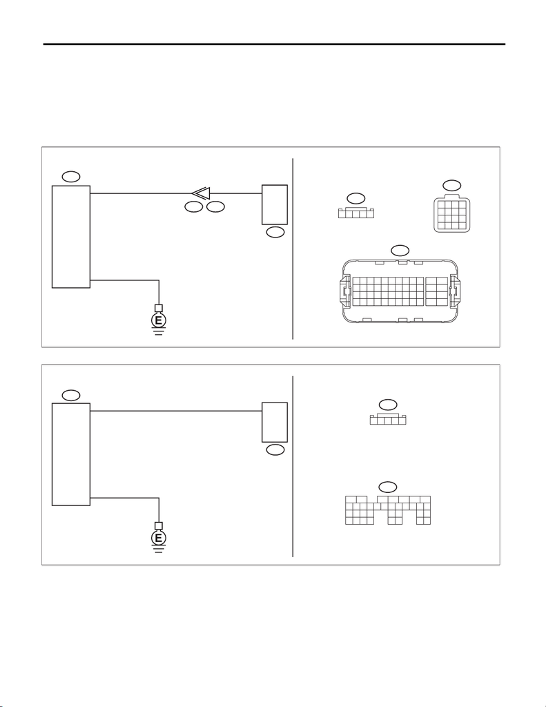

KPS(diag)-107

Diagnostic Procedure with Diagnostic Trouble Code (DTC)

KEYLESS ACCESS WITH PUSH BUTTON START SYSTEM (DIAGNOSTICS)

2. C0 MODEL

DTC DETECTING CONDITION:

Communication error between ID code box and ECM

TROUBLE SYMPTOM:

Engine will not start.

WIRING DIAGRAM:

Push button start system <Ref. to WI-329, WIRING DIAGRAM, Push Button Start System.>

• Engine type: FA

• Engine type: EJ

B422

12345

B422

15 1613 14

11

12

9

10

7856

341

2

B22

7

9

10

8

5

23

11 12

6

19

21

22

20

17

24

35 36

47 48

18

31

33

34

32

29 30

43

45

46

44

41 42

3

4

12

15

16

13 14

27

28

25 26

39

40

37 38

B:

E158

14

B43

5

4

B:

E158

SL-02800

ECM

ID CODE BOX

B422

12345

5

4

B422

29

10 11 12 13 14 15

2524

16

30

98

17 18 19

20

28

21 22 23

3231

26 27

33 34 35

B25

B:

B135

SL-02801

ECM

ID CODE BOX

[figure not shown]

KPS(diag)-108

Diagnostic Procedure with Diagnostic Trouble Code (DTC)

KEYLESS ACCESS WITH PUSH BUTTON START SYSTEM (DIAGNOSTICS)

Step Check Yes No

1 CHECK CURRENT DATA.

1) Turn the ignition switch to ON.

2) Check the keyless access CM data using

the Subaru Select Monitor.

3) Display the next data. “Immobilizer” “Engine

start” “Unlock confirmation”

Data

Immobilizer = Unset:

Engine start = Engine start permission:

Unlock confirmation = Confirmed:

Is the data displayed as

described above?

Go to step 2. Perform diagnos-

tics with phenome-

non. <Ref. to

KPS(diag)-141,

ENGINE DOES

NOT START,

INSPECTION,

Diagnostics with

Phenomenon.>

2 CHECK CURRENT DATA.

Use the Subaru Select Monitor to check the

keyless access CM data when holding down the

push button ignition switch while depressing the

brake pedal (except for MT model) or the clutch

pedal (MT model).

Data

EGI code reception status = Reception:

NOTE:

If “Reception” is displayed, the status changes

to “Not yet received” in 10 seconds. When per-

forming the check again, perform the check af-

ter turning the ignition to OFF.

Is the data displayed as

described above?

Go to step 3. Repair or replace

the harness

between ID code

box and ECM.

3 CHECK WIRING HARNESS.

1) Turn the ignition switch to OFF.

2) Disconnect the ID code box connector and

the ECM connector.

3) Using a tester, measure the resistance

between ID code box connector and ECM.

Connector & terminal

Engine type: FA

(B422) No. 4 — (E158) No. 43:

Engine type: EJ

(B422) No. 4 — (B135) No. 25:

Is the resistance less than 10

Ω?

Go to step 4. Repair or replace

the open circuit of

harness.

4 CHECK WIRING HARNESS.

Using a tester, measure the resistance between

ID code box connector and chassis ground.

Connector & terminal

(B422) No. 5 — Chassis ground:

Is the resistance less than 10

Ω?

Go to step 5. Repair or replace

the open circuit of

harness.

5 CHECK ECM.

1) Install the ECM from other normal operating

vehicle (with push button start) which use same

ECM to the vehicle to be diagnosed.

2) Perform ECM registration. Refer to the

“REGISTRATION MANUAL FOR IMMOBI-

LIZER”.

Is ECM registration finished?

And does the engine start?

Replace the ECM.

<Ref. to FU(w/o

STI)-132,

REMOVAL, Engine

Control Module

(ECM).> <Ref. to

FU(STI)-56,

REMOVAL, Engine

Control Module

(ECM).> Install the

ECM from other

vehicle to the origi-

nal vehicle.

Replace the ID

code box. <Ref. to

SL-103, NOTE, ID

Code Box.>

[figure not shown]

KPS(diag)-109

Diagnostic Procedure with Diagnostic Trouble Code (DTC)

KEYLESS ACCESS WITH PUSH BUTTON START SYSTEM (DIAGNOSTICS)

AM:DTC B1576 EGI CONTROL MODULE EEPROM

DTC DETECTING CONDITION:

• ECM malfunctioning

• When the ROM in ECM was inaccessible during registration.

AN:DTC B1577 IMM CONTROL MODULE EEPROM

1. EXCEPT FOR C0 MODEL

DTC DETECTING CONDITION:

• Defective keyless access CM

• When inaccessible to ROM in keyless access CM.

2. C0 MODEL

DTC DETECTING CONDITION:

• ID code box malfunction

• When inaccessible to ROM in ID code box.

Step Check Yes No

1 PERFORM ECM REGISTRATION.

Perform ECM registration. Refer to the “REGIS-

TRATION MANUAL FOR IMMOBILIZER”.

Is ECM registration complete? Make sure that the

engine can start.

This completes the

work.

Go to step 2.

2 PERFORM ECM REGISTRATION.

Perform ECM registration. Refer to the “REGIS-

TRATION MANUAL FOR IMMOBILIZER”.

Is ECM registration complete? Make sure that the

engine can start.

This completes the

work.

Go to step 3.

3 PERFORM ECM REGISTRATION.

Perform ECM registration. Refer to the “REGIS-

TRATION MANUAL FOR IMMOBILIZER”.

Is ECM registration complete? Make sure that the

engine can start.

This completes the

work.

Replace the ECM.

<Ref. to FU(w/o

STI)-132,

REMOVAL, Engine

Control Module

(ECM).> <Ref. to

FU(STI)-56,

REMOVAL, Engine

Control Module

(ECM).>

Step Check Yes No

1 CHECK DTC.

1) Turn the ignition switch to ON.

2) Perform the clear memory operation of

ECM.

3) Turn the ignition switch to OFF.

4) Remove and install the battery.

5) Turn the ignition switch to ON.

6) After 5 seconds or more, read DTC.

Is B1577 displayed? Replace the key-

less access CM.

<Ref. to SL-100,

Keyless Access

CM.>

System is normal.

Step Check Yes No

1 CHECK DTC.

1) Turn the ignition switch to ON.

2) Perform the clear memory operation of

ECM.

3) Turn the ignition switch to OFF.

4) Register the ID code box.

5) Read the DTC again.

Is B1577 displayed? Replace the ID

code box. <Ref. to

SL-103, ID Code

Box.>

System is normal.